# Text analysis with R

Julia Müller

Data Café Kiel, June 29 2023

# Introductions

## About me

- based at University of Freiburg
- PhD in psycholinguistics on transfer effects German -> English (in progress…)
- classes on the linguistic structure of names, corpus linguistics, statistical analyses with R
- co-organiser of R-Ladies Freiburg and Julia Gender Inclusive

To get in touch with me: julia.mueller@anglistik.uni-freiburg.de Twitter: JuliaMuellerFr

## About you

-> go to menti.com and enter code 3102 4327

# Schedule

1. reading in and preparing text data (tidy text)
2. analysing word and n-gram frequencies – break –
3. comparing word frequencies across texts
4. word and document frequencies
5. sentiment analysis

# 0 Prerequisites

## R-Markdown

- we’ll work in R-Markdown file
- includes code, but also (formatted) text, pictures, etc.
- read by default as text and not attempted to be run as code, unless in a code block
- helpful for reproducible, well-documented analyses
- In an R-Markdown document (like this one), R Code must be in a “code chunk”:

-> to add, click the green C (upper right) - R interprets anything in this block as code - be careful not to accidentally delete some of the backticks

Run code: - click on the line and press Ctrl + Enter (Windows) or Cmd + Enter (Mac) - or: click on the green arrow

Result is shown right under the block:

```r
5+2
```

```
## [1] 7
```

```r
# This is a comment and will be ignored by R
```

## Packages - please install the ones you don’t have already, then load them:

```r
library(tidytext) #for text mining specifically
library(gutenbergr) #to access full-text books that are in the public domain
library(scales) # for visualising percentages
library(readtext) # for reading in txt files
library(igraph) # for creating networks of bigrams
library(ggraph) # for visualising networks of bigrams
library(textdata) #for afinn sentiment score dictionary
library(sentimentr) #for sentence-based sentiment scores
library(viridis) #optional - for colour palettes
library(magrittr) #for different pipes
library(tidyverse) #for various data manipulation tasks
```

## The pipe %>%

The tidyverse is both a collection of packages and a “dialect” of R that has some different underlying logic when compared to “base-R” (aka, non-tidyverse coding in R)

One of the most noticeable features of the tidyverse is the pipe %>% (keyboard shortcut: Ctrl/Cmd + Shift + M).

The pipe takes the item before it and feeds it to the following command as the first argument. Since all tidyverse (and many non-tidyverse) functions take the dataframe as the first argument, this can be used to string together multiple functions. It also makes it easier to read sequential code in a more natural order.

We’ll use data processing pipelines that start with the data frame, which is then piped through several commands to get it ready for analysis.

Have a look at this code (but don’t try to run it):

```r
some_text %>% # format: one line contains several words/an entire chapter
  unnest_tokens(word, text) %>% # one line contains one word ("tidy text")
  mutate(word = str_extract(word, "[a-z']+")) %>% # remove non-alphanumeric characters
  anti_join(stop_words) %>%  # remove stop words
  drop_na() %>% # delete missing values (empty lines)
  count(word) # count how often each word occurs in the text
# -> ready for analysis/graphs!
```

# 1 Reading in and preparing texts

## Reading in text data

### Reading .txt files

Here’s how you can read in one .txt file that is saved in the “data” subfolder relative to the location of your script:

```r
hf <- readtext("data/Adventures of Huckleberry Finn.txt") %>%
  as_tibble()

hf
```

```
## # A tibble: 1 × 2
##   doc_id                             text
##   <chr>                              <chr>
## 1 Adventures of Huckleberry Finn.txt "Adventures of Huckleberry FinnTwain, Mark…
```

If you want to read all files from a sub-folder, type the name of the folder followed by / and * to ask R to read in all files in that folder:

```r
shakes <- readtext("ShakespeareTexts/*") %>%
  as_tibble()

head(shakes)
```

```
## # A tibble: 6 × 2
##   doc_id               text
##   <chr>                <chr>
## 1 As You Like It.txt   "AS YOU LIKE IT\n\nby William Shakespeare\n\n\nSCENE:\n\…
## 2 Hamlet.txt           "HAMLET, PRINCE OF DENMARK\n\nby William Shakespeare\n\n…
## 3 Henry V.txt          "The Life of Henry the Fift\n\nEnter Prologue.\n\nO For …
## 4 Julius Caesar.txt    "THE TRAGEDY OF JULIUS CAESAR\n\nby William Shakespeare\…
## 5 King Lear.txt        "THE TRAGEDY OF KING LEAR\n\nby William Shakespeare\n\n\…
## 6 King Richard III.txt "KING RICHARD III\n\nby William Shakespeare\n\n\nDramati…
```

Let’s clean the doc_id column up by removing the file ending “.txt”:

```r
shakes <- shakes %>%
  mutate(doc_id = str_remove(doc_id, ".txt"))

head(shakes)
```

```
## # A tibble: 6 × 2
##   doc_id           text
##   <chr>            <chr>
## 1 As You Like It   "AS YOU LIKE IT\n\nby William Shakespeare\n\n\nSCENE:\n\nOLI…
## 2 Hamlet           "HAMLET, PRINCE OF DENMARK\n\nby William Shakespeare\n\n\n\n…
## 3 Henry V          "The Life of Henry the Fift\n\nEnter Prologue.\n\nO For a Mu…
## 4 Julius Caesar    "THE TRAGEDY OF JULIUS CAESAR\n\nby William Shakespeare\n\nS…
## 5 King Lear        "THE TRAGEDY OF KING LEAR\n\nby William Shakespeare\n\n\n\n\…
## 6 King Richard III "KING RICHARD III\n\nby William Shakespeare\n\n\nDramatis Pe…
```

### Book data from Project Gutenberg

- Project Gutenberg: free downloads of books in the public domain (i.e. lots of classic literature)
- Still accessible via the R package gutenbergr by ID
- Top 100 books for inspiration (changes daily based on demand): https://www.gutenberg.org/browse/scores/top
- Catalog: https://www.gutenberg.org/catalog/

To find the id of a book (some have multiple copies):

```r
gutenberg_metadata %>%
  filter(title %in% c("Alice's Adventures in Wonderland", "Grimms' Fairy Tales", "Andersen's Fairy Tales"))
```

```
## # A tibble: 8 × 8
##   gutenberg_id title     author gutenberg_author_id language gutenberg_bookshelf
##          <int> <chr>     <chr>                <int> <chr>    <chr>
## 1           11 Alice's … Carro…                   7 en       Children's Literat…
## 2         1597 Andersen… Ander…                2298 en       Best Books Ever Li…
## 3         2591 Grimms' … <NA>                    NA en       <NA>
## 4        19033 Alice's … Carro…                   7 en       Children's Literat…
## 5        19573 Alice's … Carro…                   7 en       Children's Literat…
## 6        19574 Andersen… Ander…                2298 en       Children's Myths, …
## 7        20027 Grimms' … <NA>                    NA en       <NA>
## 8        23716 Alice's … Carro…                   7 en       Children's Literat…
## # ℹ 2 more variables: rights <chr>, has_text <lgl>
```

Can also search by author name:

```r
gutenberg_works(author == "Carroll, Lewis")
```

```
## # A tibble: 20 × 8
##    gutenberg_id title    author gutenberg_author_id language gutenberg_bookshelf
##           <int> <chr>    <chr>                <int> <chr>    <chr>
##  1           11 "Alice'… Carro…                   7 en       Children's Literat…
##  2           12 "Throug… Carro…                   7 en       Best Books Ever Li…
##  3           13 "The Hu… Carro…                   7 en       Children's Literat…
##  4          620 "Sylvie… Carro…                   7 en       <NA>
##  5          651 "Phanta… Carro…                   7 en       <NA>
##  6         4763 "The Ga… Carro…                   7 en       Philosophy
##  7        19002 "Alice'… Carro…                   7 en       Children's Literat…
##  8        28696 "Symbol… Carro…                   7 en       Philosophy
##  9        28885 "Alice'… Carro…                   7 en       Banned Books from …
## 10        29042 "A Tang… Carro…                   7 en       Mathematics
## 11        29888 "The Hu… Carro…                   7 en       <NA>
## 12        33582 "Rhyme?… Carro…                   7 en       <NA>
## 13        35497 "Three … Carro…                   7 en       <NA>
## 14        35535 "Feedin… Carro…                   7 en       <NA>
## 15        36308 "Songs … Carro…                   7 en       <NA>
## 16        38065 "Eight … Carro…                   7 en       <NA>
## 17        48630 "Sylvie… Carro…                   7 en       <NA>
## 18        48795 "Sylvie… Carro…                   7 en       <NA>
## 19        55040 "The Nu… Carro…                   7 en       <NA>
## 20        59111 "Index … Carro…                   7 en       <NA>
## # ℹ 2 more variables: rights <chr>, has_text <lgl>
```

```r
gutenberg_works(str_detect(author, "Carroll")) #if you only have a partial name
```

```
## # A tibble: 34 × 8
##    gutenberg_id title    author gutenberg_author_id language gutenberg_bookshelf
##           <int> <chr>    <chr>                <int> <chr>    <chr>
##  1           11 "Alice'… Carro…                   7 en       Children's Literat…
##  2           12 "Throug… Carro…                   7 en       Best Books Ever Li…
##  3           13 "The Hu… Carro…                   7 en       Children's Literat…
##  4          620 "Sylvie… Carro…                   7 en       <NA>
##  5          651 "Phanta… Carro…                   7 en       <NA>
##  6         4763 "The Ga… Carro…                   7 en       Philosophy
##  7         5994 "Our Ne… Carro…                1906 en       Psychology
##  8        16861 "The We… Goodw…                6978 en       <NA>
##  9        19002 "Alice'… Carro…                   7 en       Children's Literat…
## 10        23160 "Solomo… Carro…               25719 en       Science Fiction
## # ℹ 24 more rows
## # ℹ 2 more variables: rights <chr>, has_text <lgl>
```

For more Gutenberg search options: https://ropensci.org/tutorials/gutenbergr_tutorial/

Once you found your books, download with gutenberg_download:

```r
fairytales_raw <- gutenberg_download(c(11, 2591, 1597))
```

```
## Determining mirror for Project Gutenberg from https://www.gutenberg.org/robot/harvest
```

```
## Using mirror http://aleph.gutenberg.org
```

```r
fairytales_raw
```

```
## # A tibble: 18,420 × 2
##    gutenberg_id text
##           <int> <chr>
##  1           11 "[Illustration]"
##  2           11 ""
##  3           11 ""
##  4           11 ""
##  5           11 ""
##  6           11 "Alice’s Adventures in Wonderland"
##  7           11 ""
##  8           11 "by Lewis Carroll"
##  9           11 ""
## 10           11 "THE MILLENNIUM FULCRUM EDITION 3.0"
## # ℹ 18,410 more rows
```

11: Alice’s Adventures in Wonderland 2591: Grimm’s Fairytales 1597: Hans Christian Anderson’s Fairytales

## Preparing data

- convert Gutenberg ID to a factor
- replace the ID numbers with more descriptive labels

```r
fairytales_raw <- fairytales_raw %>%
  mutate(gutenberg_id = as_factor(gutenberg_id),
         gutenberg_id = fct_recode(gutenberg_id,
                                   "Alice's Adventures in Wonderland" = "11",
                                   "Grimm's Fairytales" = "2591",
                                   "Hans Christian Anderson's Fairytales" = "1597"))
```

## Preparing texts - tidy text

The tidy text format: - has one token per row - token = often a word, or n-gram - facilitates analyses (easily lets us count how often which token occurs)

### the unnest_tokens function

- Easy to convert from full text to token per row with unnest_tokens() Syntax: unnest_tokens(df, newcol, oldcol)
- unnest_tokens() automatically removes punctuation and converts to lowercase (unless you set to_lower = FALSE)
- by default, tokens are set to words, but you can also use token = “characters”, “ngrams”, “sentences”, “lines”, “regex”, “paragraphs”

```r
(fairytales_tidy <- fairytales_raw %>%
  unnest_tokens(word, text))
```

```
## # A tibble: 184,542 × 2
##    gutenberg_id                     word
##    <fct>                            <chr>
##  1 Alice's Adventures in Wonderland illustration
##  2 Alice's Adventures in Wonderland alice’s
##  3 Alice's Adventures in Wonderland adventures
##  4 Alice's Adventures in Wonderland in
##  5 Alice's Adventures in Wonderland wonderland
##  6 Alice's Adventures in Wonderland by
##  7 Alice's Adventures in Wonderland lewis
##  8 Alice's Adventures in Wonderland carroll
##  9 Alice's Adventures in Wonderland the
## 10 Alice's Adventures in Wonderland millennium
## # ℹ 184,532 more rows
```

```r
# this keeps the information on which sentence the words came from
fairytales_raw %>%
  unnest_tokens(sentence, text, token = "sentences") %>%
  mutate(sent_nr = row_number()) %>%
  unnest_tokens(word, sentence)
```

```
## # A tibble: 184,542 × 3
##    gutenberg_id                     sent_nr word
##    <fct>                              <int> <chr>
##  1 Alice's Adventures in Wonderland       1 illustration
##  2 Alice's Adventures in Wonderland       2 alice’s
##  3 Alice's Adventures in Wonderland       2 adventures
##  4 Alice's Adventures in Wonderland       2 in
##  5 Alice's Adventures in Wonderland       2 wonderland
##  6 Alice's Adventures in Wonderland       3 by
##  7 Alice's Adventures in Wonderland       3 lewis
##  8 Alice's Adventures in Wonderland       3 carroll
##  9 Alice's Adventures in Wonderland       4 the
## 10 Alice's Adventures in Wonderland       4 millennium
## # ℹ 184,532 more rows
```

### TRY IT

Use the `unnest_tokens()` function on the Shakespeare texts to split them into words. Save the resulting data frame as shakes_unnest.

```r
(shakes_unnest <- shakes %>%
  unnest_tokens(word, text))
```

```
## # A tibble: 338,557 × 2
##    doc_id         word
##    <chr>          <chr>
##  1 As You Like It as
##  2 As You Like It you
##  3 As You Like It like
##  4 As You Like It it
##  5 As You Like It by
##  6 As You Like It william
##  7 As You Like It shakespeare
##  8 As You Like It scene
##  9 As You Like It oliver's
## 10 As You Like It house
## # ℹ 338,547 more rows
```

### Removing non-alphanumeric characters

- Project Gutenberg data sometimes contains underscores to indicate italics
- str_extract is used to get rid of non-alphanumeric characters (because we don’t want to count *word* separately from word)

```r
fairytales_tidy <- fairytales_tidy %>%
  mutate(word = str_extract(word, "[a-z']+"))

shakes_unnest <- shakes_unnest %>%
  mutate(word = str_extract(word, "[a-z']+"))
```

### Removing stop words

- Stop words: very common, “meaningless” function words like “the”, “of” and “to” – not usually important in an analysis (i.e. to find out that the most common word in two books you are comparing is “the”)
- tidytext has a built-in df called stop_words for English
- remove these from your dataset with anti_join

We can take a look:

```r
stop_words
```

```
## # A tibble: 1,149 × 2
##    word        lexicon
##    <chr>       <chr>
##  1 a           SMART
##  2 a's         SMART
##  3 able        SMART
##  4 about       SMART
##  5 above       SMART
##  6 according   SMART
##  7 accordingly SMART
##  8 across      SMART
##  9 actually    SMART
## 10 after       SMART
## # ℹ 1,139 more rows
```

```r
(fairytales_tidy <- fairytales_tidy %>%
  anti_join(stop_words))
```

```
## # A tibble: 54,752 × 2
##    gutenberg_id                     word
##    <fct>                            <chr>
##  1 Alice's Adventures in Wonderland illustration
##  2 Alice's Adventures in Wonderland alice
##  3 Alice's Adventures in Wonderland adventures
##  4 Alice's Adventures in Wonderland wonderland
##  5 Alice's Adventures in Wonderland lewis
##  6 Alice's Adventures in Wonderland carroll
##  7 Alice's Adventures in Wonderland millennium
##  8 Alice's Adventures in Wonderland fulcrum
##  9 Alice's Adventures in Wonderland edition
## 10 Alice's Adventures in Wonderland <NA>
## # ℹ 54,742 more rows
```

```r
(shakes_unnest <- shakes_unnest %>%
  anti_join(stop_words))
```

```
## # A tibble: 146,214 × 2
##    doc_id         word
##    <chr>          <chr>
##  1 As You Like It william
##  2 As You Like It shakespeare
##  3 As You Like It scene
##  4 As You Like It oliver's
##  5 As You Like It house
##  6 As You Like It frederick's
##  7 As You Like It court
##  8 As You Like It forest
##  9 As You Like It arden
## 10 As You Like It act
## # ℹ 146,204 more rows
```

Define other stop words:

```r
meaningless_words <- tibble(word = c("von", "der", "thy", "thee", "thou"))

fairytales_tidy <- fairytales_tidy %>%
  anti_join(meaningless_words)
```

This could also be used to remove character names, for example.

The stopwords package also contains lists of stopwords for other languages, so to get a list of German stopwords, you could use:

```r
library(stopwords)
stop_german <- data.frame(word = stopwords::stopwords("de"), stringsAsFactors = FALSE)
```

More info: https://cran.r-project.org/web/packages/stopwords/readme/README.html

# 2 Analysing word and n-gram frequencies

## Word frequencies

### Find most frequent words

- Easily find frequent words using count()
- Data must be in tidy format (one token per line)
- sort = TRUE to show the most frequent words first

tidy_books %>% count(word, sort = TRUE)

These are the most frequent words across all books:

```r
fairytales_tidy %>%
  count(word, sort = TRUE) # R automatically creates a new column, calls it n, and writes the frequencies in it
```

```
## # A tibble: 7,407 × 2
##    word       n
##    <chr>  <int>
##  1 king     459
##  2 alice    399
##  3 time     334
##  4 day      278
##  5 looked   254
##  6 tree     243
##  7 home     233
##  8 head     228
##  9 door     223
## 10 mother   215
## # ℹ 7,397 more rows
```

But it makes more sense to look at frequent words for each of the three books separately by adding a grouping variable:

```r
fairytales_freq <- fairytales_tidy %>%
  group_by(gutenberg_id) %>% #including this ensures that the counts are by book and the id column is retained
  count(word, sort=TRUE) %>%
  ungroup() # to undo the grouping

fairytales_freq
```

```
## # A tibble: 11,096 × 3
##    gutenberg_id                     word       n
##    <fct>                            <chr>  <int>
##  1 Alice's Adventures in Wonderland alice    399
##  2 Grimm's Fairytales               king     368
##  3 Grimm's Fairytales               time     207
##  4 Grimm's Fairytales               day      192
##  5 Grimm's Fairytales               father   183
##  6 Grimm's Fairytales               home     180
##  7 Grimm's Fairytales               mother   154
##  8 Grimm's Fairytales               cried    153
##  9 Grimm's Fairytales               wife     152
## 10 Grimm's Fairytales               door     143
## # ℹ 11,086 more rows
```

`filter()` can be used to look at subsets of the data, i.e. one book, all words with freq above 100, etc. Note here that I don’t save this output!

```r
fairytales_freq %>%
  filter(gutenberg_id == "Grimm's Fairytales")
```

```
## # A tibble: 4,270 × 3
##    gutenberg_id       word       n
##    <fct>              <chr>  <int>
##  1 Grimm's Fairytales king     368
##  2 Grimm's Fairytales time     207
##  3 Grimm's Fairytales day      192
##  4 Grimm's Fairytales father   183
##  5 Grimm's Fairytales home     180
##  6 Grimm's Fairytales mother   154
##  7 Grimm's Fairytales cried    153
##  8 Grimm's Fairytales wife     152
##  9 Grimm's Fairytales door     143
## 10 Grimm's Fairytales fell     130
## # ℹ 4,260 more rows
```

```r
fairytales_freq %>%
  filter(n > 200)
```

```
## # A tibble: 3 × 3
##   gutenberg_id                     word      n
##   <fct>                            <chr> <int>
## 1 Alice's Adventures in Wonderland alice   399
## 2 Grimm's Fairytales               king    368
## 3 Grimm's Fairytales               time    207
```

### TRY IT

Using the unnested Shakespeare data, count how often each word occurs. Make sure to have R count separately for each play and save the resulting table as shakes_freq.

```r
shakes_freq <- shakes_unnest %>%
  group_by(doc_id) %>%
  count(word, sort = TRUE) %>%
  ungroup()

shakes_freq
```

```
## # A tibble: 47,613 × 3
##    doc_id              word         n
##    <chr>               <chr>    <int>
##  1 Tempest             <NA>       869
##  2 Julius Caesar       brutus     361
##  3 Hamlet              ham        358
##  4 Othello             iago       341
##  5 Romeo and Juliet    romeo      296
##  6 Shakespeare_Sonnets thy        281
##  7 Romeo and Juliet    thou       276
##  8 As You Like It      rosalind   263
##  9 King Richard III    king       260
## 10 Henry V             king       250
## # ℹ 47,603 more rows
```

#### Plotting word frequencies - bar graphs

Bar graph of top words in Grimm’s fairytales

Basic graph:

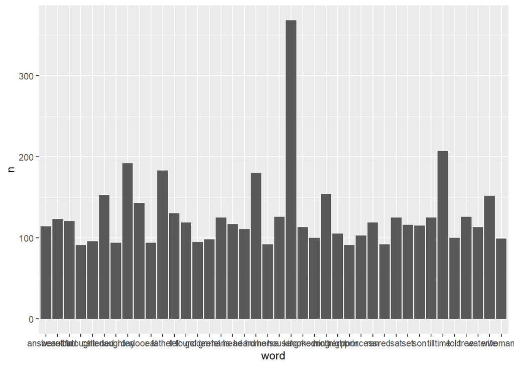

```r
fairytales_freq %>%
  filter(n>90 & gutenberg_id == "Grimm's Fairytales") %>%  # filtering to a frequency of at least 90 to ensure the plot isn't too cluttered
  ggplot(aes(x=word, y=n)) +
  geom_col()
```

Readable labels:

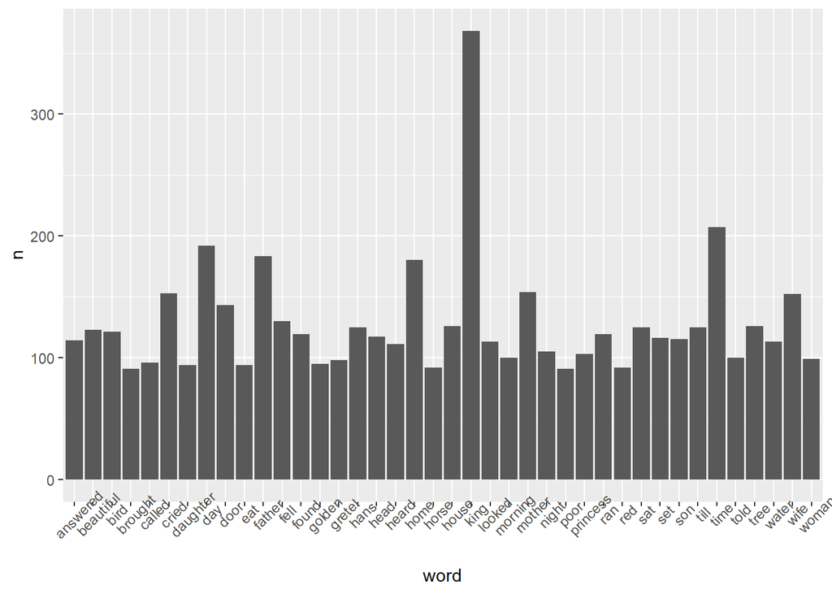

```r
fairytales_freq %>%
  filter(n>90 & gutenberg_id == "Grimm's Fairytales") %>%
  ggplot(aes(x=word, y=n)) +
  geom_col() +
  theme(axis.text.x = element_text(angle = 45)) # x-axis labels (words) at a 45° angle
```

Descending order:

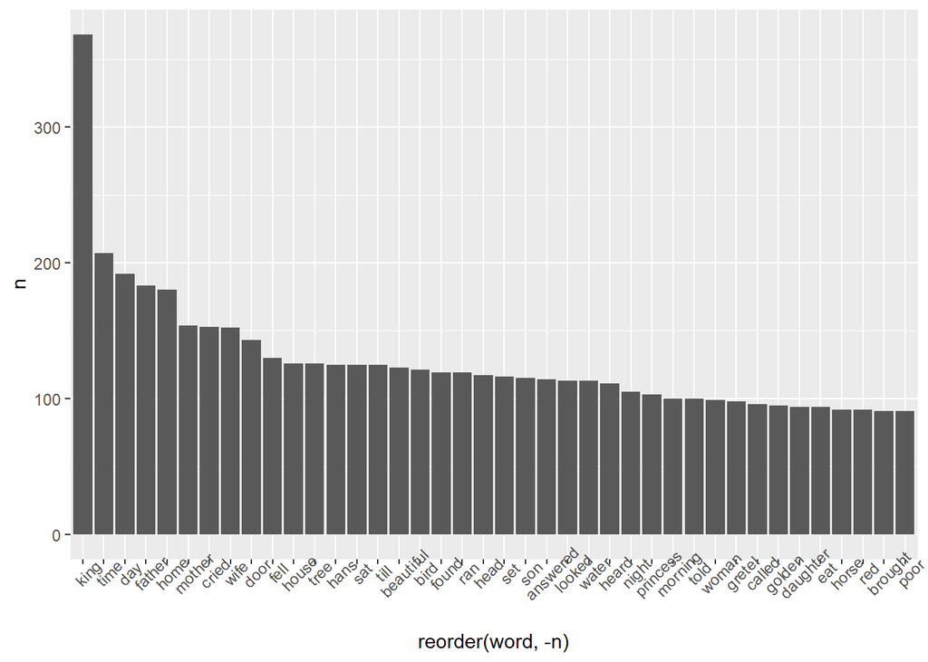

```r
fairytales_freq %>%
  filter(n>90 & gutenberg_id == "Grimm's Fairytales") %>%
  ggplot(aes(x=reorder(word, -n), y=n)) + # reorder words by frequency in descending order because -n (use n for ascending order)
  geom_col() +
  theme(axis.text.x = element_text(angle = 45))
```

Axis names and a nicer-looking theme:

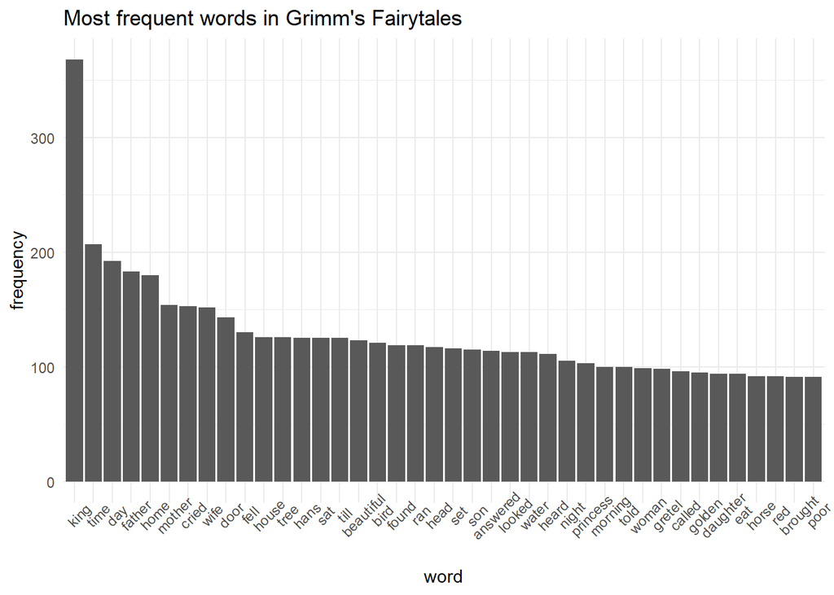

```r
fairytales_freq %>%
  filter(n>90 & gutenberg_id == "Grimm's Fairytales") %>%
  ggplot(aes(x=reorder(word, -n), y=n)) +
  geom_col() +
  theme_minimal() +
  theme(axis.text.x = element_text(angle = 45)) +
  labs(x = "word",
       y = "frequency",
       title = "Most frequent words in Grimm's Fairytales")
```

Or: flip coordinate system to make more space for words

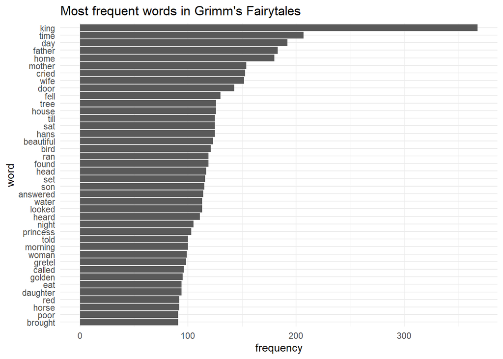

```r
fairytales_freq %>%
  filter(n>90 & gutenberg_id == "Grimm's Fairytales") %>%
  ggplot(aes(x=reorder(word, n), y=n)) +
  geom_col() +
  labs(x = "word",
       y = "frequency",
       title = "Most frequent words in Grimm's Fairytales") +
  coord_flip() +
  theme_minimal()
```

We can also use colour to indicate which book a word is from:

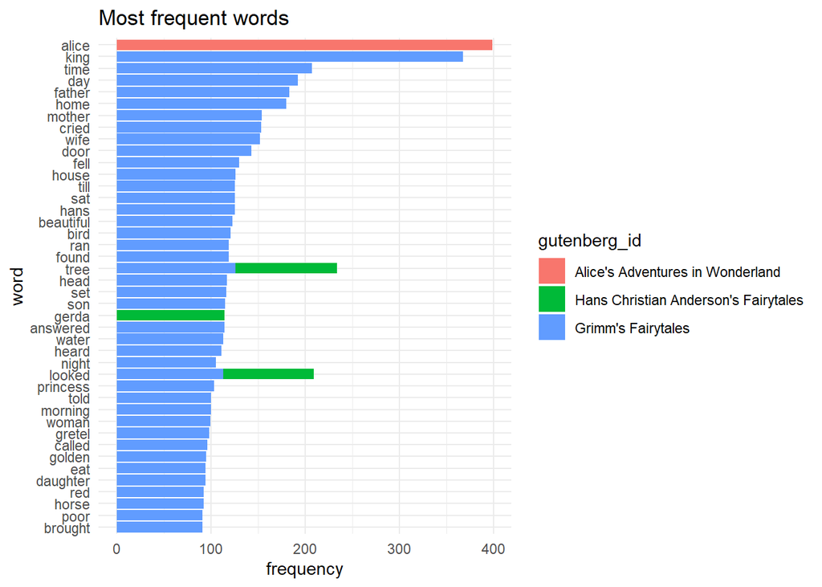

```r
fairytales_freq %>%
  filter(n > 90) %>%
  ggplot(aes(x=reorder(word, n), y=n, fill = gutenberg_id)) + # fill in the bars according to which book the word is from
  geom_col() +
  labs(x = "word",
       y = "frequency",
       title = "Most frequent words") +
  coord_flip() +
  theme_minimal()
```

But we can see that the differing lengths of the book heavily skew the picture. We could normalise the frequency (see section below).

Alternatively, we can find and plot the top n words from each book by adding a facet:

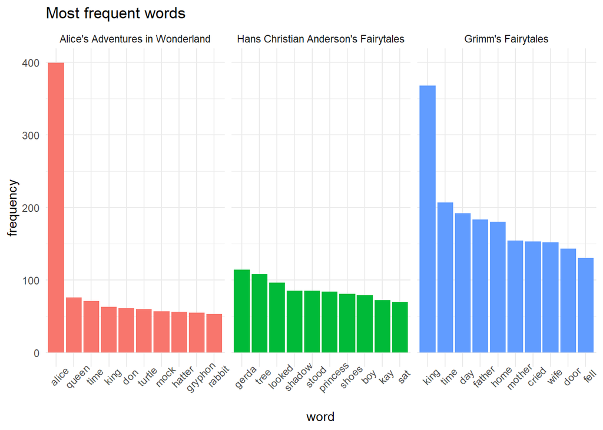

```r
fairytales_freq %>%
  group_by(gutenberg_id) %>%
  slice_max(order_by = n, n = 10) %>%  # find the ten words with the highest frequencies separately for each book
  ggplot() +
  # when reordering with a facet, use reorder_within() and scale_x_reordered()
  aes(x = reorder_within(word, -n, gutenberg_id), y = n, fill = gutenberg_id) +
  geom_col() +
  facet_wrap(~gutenberg_id, scales = "free_x") +
  theme_minimal() +
  scale_x_reordered() +
  theme(legend.position = "none",
        axis.text.x = element_text(angle = 45)) +
  labs(x = "word",
       y = "frequency",
       title = "Most frequent words")
```

##### TRY IT

Working with the Shakespeare data: (a) pick one play, filter the data down to it, and visualise the most frequent words (b) visualise the ten most frequent words for each play, using a facet (advanced!)

Tip for both options: Copy-paste the code, then change the data frame, variable names, etc.

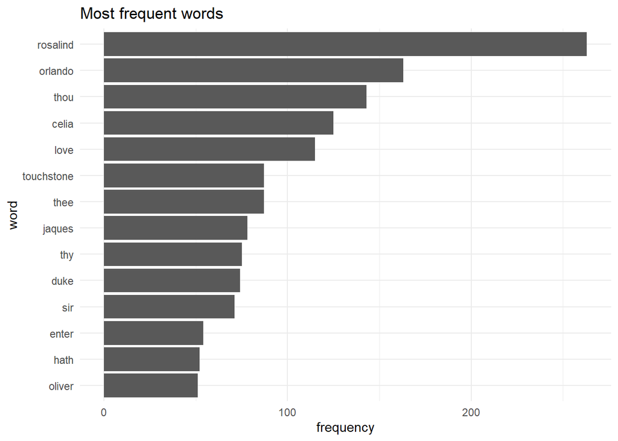

```r
shakes_freq %>%
  filter(n > 50 & doc_id == "As You Like It") %>%
  ggplot(aes(x=reorder(word, n), y=n)) +
  geom_col() +
  labs(x = "word",
       y = "frequency",
       title = "Most frequent words") +
  coord_flip() +
  theme_minimal()
```

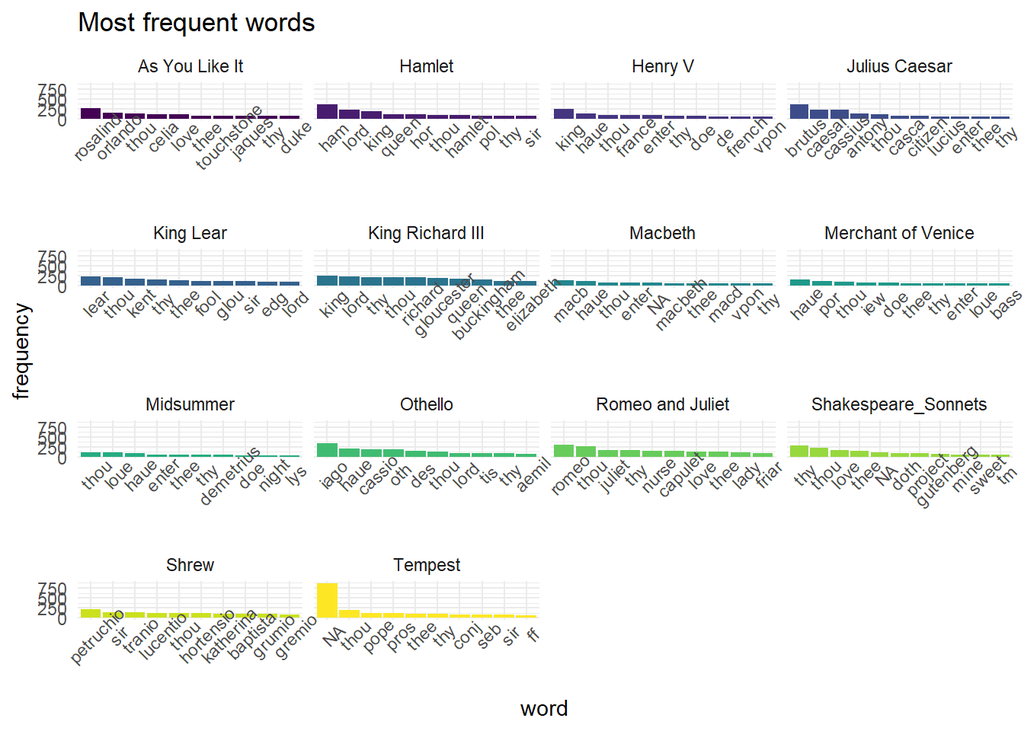

```r
shakes_freq %>%
  group_by(doc_id) %>%
  slice_max(order_by = n, n = 10) %>%
  ungroup() %>%
  ggplot() +
  aes(x = reorder_within(word, -n, doc_id), y = n, fill = doc_id) +
  geom_col() +
  theme_minimal() +
  scale_x_reordered() +
  theme(legend.position = "none",
        axis.text.x = element_text(angle = 45)) +
  labs(x = "word",
       y = "frequency",
       title = "Most frequent words") +
  facet_wrap(~doc_id, scales = "free_x") +
  scale_fill_viridis(discrete = TRUE)
```

### Normalised frequency

- when comparing the frequencies of words from different texts, they are commonly normalised
- convention in corpus linguistics: report the frequency per 1 million words
- for shorter texts: per 10,000 or per 100,000 words
- calculation: raw frequency * 1,000,000 / total numbers in text
- First, we need to re-do the unnesting and word-cleaning process because we want to keep stopwords to count how many words each play has in total
- We add this information with `add_count()`

```r
shakes_freq <- shakes %>%
  unnest_tokens(word, text) %>% # one word per line
  mutate(word = str_extract(word, "[a-z']+")) %>% # remove non-alphanumeric characters
  drop_na() %>% # delete empty lines
  group_by(doc_id) %>%
  count(word) %>%
  ungroup() %>%
  add_count(doc_id, wt = n) %>% # total number of words in text now in nn column
  mutate(pmw = n * 1000000/nn) %>% # calculating normalised frequency per million words
  anti_join(stop_words) # removing stopwords afterwards
```

```
## Storing counts in `nn`, as `n` already present in input
## ℹ Use `name = "new_name"` to pick a new name.
```

```r
shakes_freq %>%
  arrange(-pmw)
```

```
## # A tibble: 47,601 × 5
##    doc_id              word         n    nn    pmw
##    <chr>               <chr>    <int> <int>  <dbl>
##  1 Julius Caesar       brutus     361 21028 17168.
##  2 Shakespeare_Sonnets thy        281 20833 13488.
##  3 Othello             iago       341 27477 12410.
##  4 Romeo and Juliet    romeo      296 25920 11420.
##  5 As You Like It      rosalind   263 23073 11399.
##  6 Shakespeare_Sonnets thou       235 20833 11280.
##  7 Hamlet              ham        358 32001 11187.
##  8 Julius Caesar       caesar     231 21028 10985.
##  9 Julius Caesar       cassius    225 21028 10700.
## 10 Romeo and Juliet    thou       276 25920 10648.
## # ℹ 47,591 more rows
```

#### Plotting normalised frequency

Now we can plot, for example, the 20 most frequent words (by pmw).

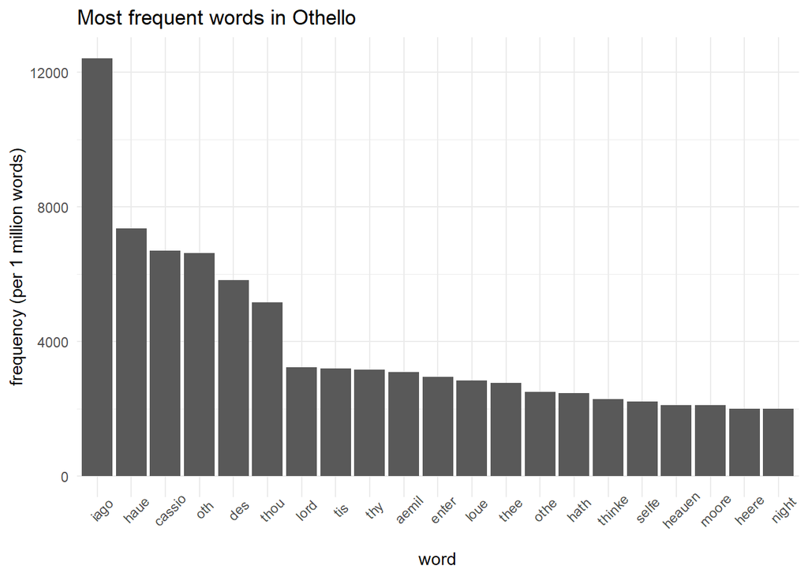

```r
shakes_freq %>%
  filter(doc_id == "Othello") %>%
  top_n(20, pmw) %>%
  ggplot(aes(x=reorder(word, -pmw), y=pmw)) +
  geom_col(show.legend=FALSE) +
  theme_minimal() +
  theme(axis.text.x = element_text(angle = 45)) +
  labs(x = "word",
       y = "frequency (per 1 million words)",
       title = "Most frequent words in Othello")
```

### Calculating percentages

We can calculate percentages in a very similar way - only the calculation in `mutate()` is different:

```r
shakes_perc <- shakes %>%
  unnest_tokens(word, text) %>%
  mutate(word = str_extract(word, "[a-z']+")) %>%
  drop_na() %>%
  group_by(doc_id) %>%
  count(word) %>%
  ungroup() %>%
  add_count(doc_id, wt = n) %>%  # total number of words in text now in nn column
  mutate(perc = n/nn * 100) %>% # calculate percentages
  anti_join(stop_words) # removing stopwords
```

```
## Storing counts in `nn`, as `n` already present in input
## ℹ Use `name = "new_name"` to pick a new name.
```

```r
shakes_perc %>%
  arrange(-perc)
```

```
## # A tibble: 47,601 × 5
##    doc_id              word         n    nn  perc
##    <chr>               <chr>    <int> <int> <dbl>
##  1 Julius Caesar       brutus     361 21028  1.72
##  2 Shakespeare_Sonnets thy        281 20833  1.35
##  3 Othello             iago       341 27477  1.24
##  4 Romeo and Juliet    romeo      296 25920  1.14
##  5 As You Like It      rosalind   263 23073  1.14
##  6 Shakespeare_Sonnets thou       235 20833  1.13
##  7 Hamlet              ham        358 32001  1.12
##  8 Julius Caesar       caesar     231 21028  1.10
##  9 Julius Caesar       cassius    225 21028  1.07
## 10 Romeo and Juliet    thou       276 25920  1.06
## # ℹ 47,591 more rows
```

#### TRY IT

Create a graph of the 20 most frequent words (by percentage) in the sonnets (doc_id == “Shakespeare_Sonnets”).

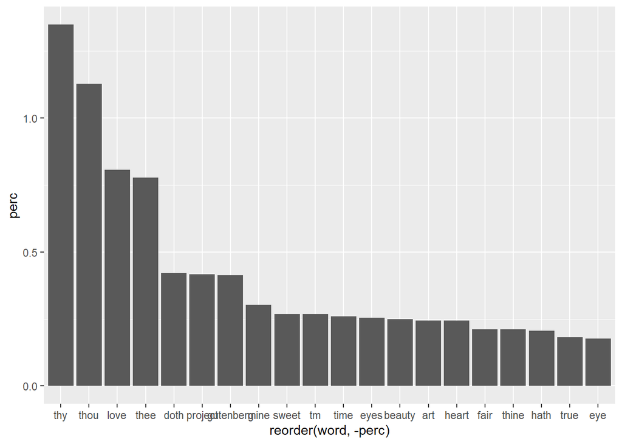

```r
shakes_perc %>%
  filter(doc_id == "Shakespeare_Sonnets") %>%
  top_n(n = 20, wt = perc) %>%
  ggplot() +
  aes(x = reorder(word, -perc), y = perc) +
  geom_col()
```

## N-grams

So far, we’ve looked at single words and how (in)frequent they are, but in this part, we’ll focus on combinations of two or more words.

Some pre-processing first, though: In the next section, we’ll only work with Alice in Wonderland. We also need information on which chapter a line occurs in for subsequent analyses, so we’ll use `cumsum()` - you can think of this as a counter that starts at 0 and counts up by 1 every time the next part of the line evaluates to TRUE. In other words, every time the regular expression in `str_detect()` finds “chapter” followed by a number or Roman numeral, the counter counts up by one. Then, we remove the column that contains the Gutenberg ID, get rid of lines in “Chapter 0”, i.e. the title, author and information on the publisher, convert chapter to a factor, and remove any underscores in the text.

```r
alice <- fairytales_raw %>%
  filter(gutenberg_id == "Alice's Adventures in Wonderland") %>%
  mutate(chapter = cumsum(str_detect(text, regex("^chapter [\\divxlc]", ignore_case = TRUE)))) %>% # if the line starts with "chapter" and is followed by a number or Roman numeral, increase the chapter counter by 1
  select(-gutenberg_id) %>% # remove Gutenberg ID column
  filter(chapter != 0) %>% # remove text before first chapter starts
  mutate(chapter = as_factor(chapter),
         text = str_remove_all(text, "_"))

alice %>%
  select(text, chapter)
```

```
## # A tibble: 3,351 × 2
##    text                                                                  chapter
##    <chr>                                                                 <fct>
##  1 "CHAPTER I."                                                          1
##  2 "Down the Rabbit-Hole"                                                1
##  3 ""                                                                    1
##  4 ""                                                                    1
##  5 "Alice was beginning to get very tired of sitting by her sister on t… 1
##  6 "bank, and of having nothing to do: once or twice she had peeped int… 1
##  7 "the book her sister was reading, but it had no pictures or"          1
##  8 "conversations in it, “and what is the use of a book,” thought Alice" 1
##  9 "“without pictures or conversations?”"                                1
## 10 ""                                                                    1
## # ℹ 3,341 more rows
```

### Unnest tokens: n-grams

The `unnest_tokens()` lets you define what should count as a token. So far, we’ve used `token = "words"`, but now we want to move on to multi-word combinations (n-grams) instead of single words.

An n-gram is a combination of consecutive words of length n. Each bigram (n = 2), for example, consist of two words. Let’s have a look:

```r
(alice_bigrams <- alice %>%
   unnest_tokens(bigram, text, token = "ngrams", n = 2))
```

```
## # A tibble: 25,170 × 2
##    chapter bigram
##    <fct>   <chr>
##  1 1       chapter i
##  2 1       down the
##  3 1       the rabbit
##  4 1       rabbit hole
##  5 1       <NA>
##  6 1       <NA>
##  7 1       alice was
##  8 1       was beginning
##  9 1       beginning to
## 10 1       to get
## # ℹ 25,160 more rows
```

Each word appears twice now: As the first and as the second word in a bigram. So the bigrams overlap.

Change the `n =` argument to control how many words each n-gram should contain:

```r
alice %>%
  unnest_tokens('4-gram', text, token = "ngrams", n = 4)
```

```
## # A tibble: 20,546 × 2
##    chapter `4-gram`
##    <fct>   <chr>
##  1 1       <NA>
##  2 1       down the rabbit hole
##  3 1       <NA>
##  4 1       <NA>
##  5 1       alice was beginning to
##  6 1       was beginning to get
##  7 1       beginning to get very
##  8 1       to get very tired
##  9 1       get very tired of
## 10 1       very tired of sitting
## # ℹ 20,536 more rows
```

### Counting n-grams

We can use commands for analysing and visualising single words to do the same for n-grams. First, let’s see how often each bigram occurs in the text:

```r
alice_bigrams %>%
  count(bigram, sort = TRUE)
```

```
## # A tibble: 13,239 × 2
##    bigram         n
##    <chr>      <int>
##  1 <NA>         951
##  2 said the     206
##  3 of the       130
##  4 said alice   112
##  5 in a          96
##  6 in the        76
##  7 and the       75
##  8 it was        73
##  9 to the        68
## 10 the queen     60
## # ℹ 13,229 more rows
```

The most common bigrams are empty lines, so let’s remove those first:

```r
alice_bigrams <- alice_bigrams %>%
    drop_na(bigram)

alice_bigrams %>%
  count(bigram) %>%
  arrange(desc(n))
```

```
## # A tibble: 13,238 × 2
##    bigram         n
##    <chr>      <int>
##  1 said the     206
##  2 of the       130
##  3 said alice   112
##  4 in a          96
##  5 in the        76
##  6 and the       75
##  7 it was        73
##  8 to the        68
##  9 the queen     60
## 10 as she        59
## # ℹ 13,228 more rows
```

### Removing stopwords from n-grams

A lot of these bigrams contain stopwords such as “the”, “a”, and “to”. To remove them, we can use the stopword list again:

```r
stop_words
```

```
## # A tibble: 1,149 × 2
##    word        lexicon
##    <chr>       <chr>
##  1 a           SMART
##  2 a's         SMART
##  3 able        SMART
##  4 about       SMART
##  5 above       SMART
##  6 according   SMART
##  7 accordingly SMART
##  8 across      SMART
##  9 actually    SMART
## 10 after       SMART
## # ℹ 1,139 more rows
```

However, this list contains single words, so we need to split up the bigrams with `separate()`:

```r
(alice_bigrams <- alice_bigrams %>%
  separate(col = bigram,
           into = c("word1", "word2"),
           sep = " ",
           remove = FALSE))
```

```
## # A tibble: 24,219 × 4
##    chapter bigram        word1     word2
##    <fct>   <chr>         <chr>     <chr>
##  1 1       chapter i     chapter   i
##  2 1       down the      down      the
##  3 1       the rabbit    the       rabbit
##  4 1       rabbit hole   rabbit    hole
##  5 1       alice was     alice     was
##  6 1       was beginning was       beginning
##  7 1       beginning to  beginning to
##  8 1       to get        to        get
##  9 1       get very      get       very
## 10 1       very tired    very      tired
## # ℹ 24,209 more rows
```

We’d like to keep the bigram column, so we need to set `remove` to FALSE. Alternatively, we can use `unite()` later to glue the single words back together into bigrams.

Next, we can remove bigrams if either word is in the stopwords data:

```r
(alice_bigrams_stop <- alice_bigrams %>%
  filter(!word1 %in% stop_words$word & !word2 %in% stop_words$word))
```

```
## # A tibble: 1,648 × 4
##    chapter bigram           word1     word2
##    <fct>   <chr>            <chr>     <chr>
##  1 1       rabbit hole      rabbit    hole
##  2 1       hot day          hot       day
##  3 1       daisy chain      daisy     chain
##  4 1       white rabbit     white     rabbit
##  5 1       pink eyes        pink      eyes
##  6 1       eyes ran         eyes      ran
##  7 1       waistcoat pocket waistcoat pocket
##  8 1       alice started    alice     started
##  9 1       waistcoat pocket waistcoat pocket
## 10 1       rabbit hole      rabbit    hole
## # ℹ 1,638 more rows
```

…and count them again:

```r
alice_bigrams_stop %>%
  count(bigram, sort = TRUE)
```

```
## # A tibble: 1,306 × 2
##    bigram             n
##    <chr>          <int>
##  1 mock turtle       50
##  2 march hare        31
##  3 white rabbit      20
##  4 poor alice        11
##  5 alice looked       8
##  6 alice replied      8
##  7 beautiful soup     8
##  8 cried alice        7
##  9 i’m afraid         7
## 10 soo oop            7
## # ℹ 1,296 more rows
```

### Plot bigram frequencies

We can now plot these bigram frequencies, similar to how we visualised word frequencies earlier.

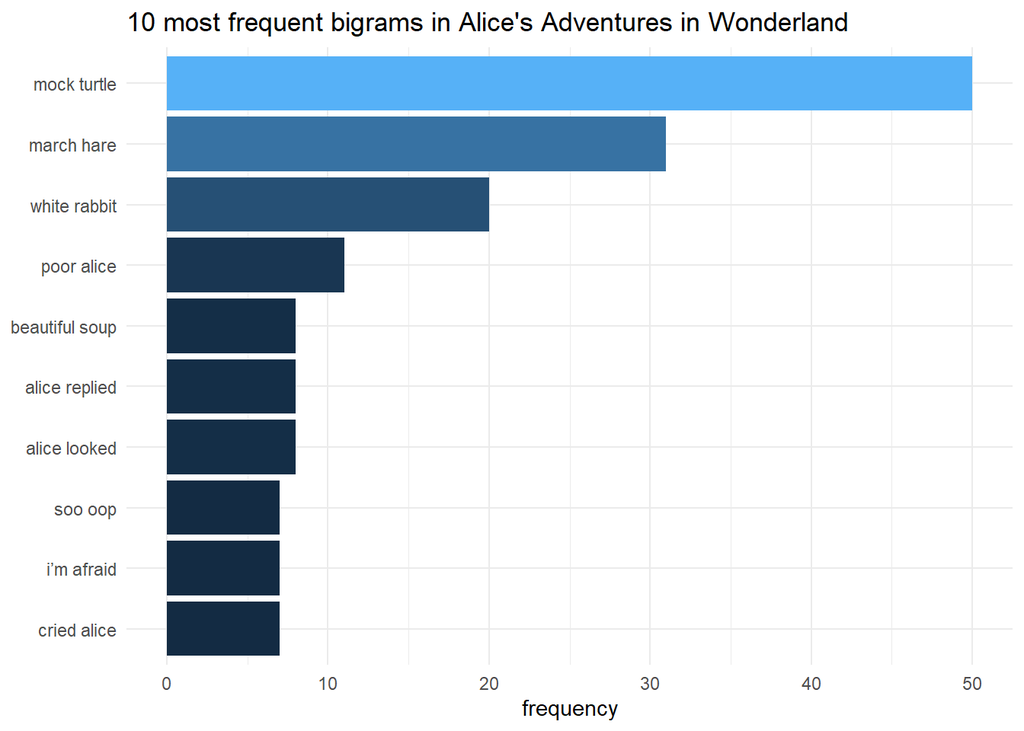

```r
alice_bigrams_stop %>%
  count(bigram, sort = TRUE) %>%
  top_n(n = 10, wt = n) %>%
  ggplot(aes(y = reorder(bigram, n),
             x = n,
             fill = n)) +
  geom_col(show.legend = FALSE) +
  labs(y = NULL, x = "frequency", title = "10 most frequent bigrams in Alice's Adventures in Wonderland") +
  theme_minimal()
```

### Filtering n-grams

To find bigrams that contain specific words, we can use `filter()`:

```r
alice_bigrams_stop %>%
  filter(word1 == "alice" | word2 == "alice") %>%
  distinct(bigram)
```

```
## # A tibble: 107 × 1
##    bigram
##    <chr>
##  1 alice started
##  2 poor alice
##  3 alice ventured
##  4 cried alice
##  5 waiting alice
##  6 mouse alice
##  7 history alice
##  8 alice hastily
##  9 passion alice
## 10 creatures alice
## # ℹ 97 more rows
```

…alternatively, we can use `str_detect()` to find instances of “alice” in the bigram column:

```r
alice_bigrams_stop %>%
  filter(str_detect(bigram, "alice")) %>%
  distinct(bigram)
```

```
## # A tibble: 112 × 1
##    bigram
##    <chr>
##  1 alice started
##  2 poor alice
##  3 alice ventured
##  4 cried alice
##  5 alice’s love
##  6 waiting alice
##  7 mouse alice
##  8 history alice
##  9 alice hastily
## 10 passion alice
## # ℹ 102 more rows
```

This applies partial matching, so e.g. “alice’s” is also found, in contrast to the first filter command.

## Creating and visualising a bigram network

Let’s visualise which words commonly co-occur in a network graph. First, we need to count the bigrams. Then, the `graph_from_data_frame()` command from the igraph package reformats the data.

```r
alice_graph <- alice_bigrams_stop %>%
  count(word1, word2) %>% # we need the words separated for this graph
  filter(n > 3) %>%
  graph_from_data_frame()

alice_graph
```

```
## IGRAPH 184e221 DN-- 50 31 --
## + attr: name (v/c), n (e/n)
## + edges from 184e221 (vertex names):
##  [1] alice    ->hastily  alice    ->looked   alice    ->replied
##  [4] alice    ->ventured beau     ->ootiful  beautiful->soup
##  [7] can’t    ->remember cheshire ->cat      cried    ->alice
## [10] father   ->william  golden   ->key      guinea   ->pigs
## [13] i’m      ->afraid   jury     ->box      kid      ->gloves
## [16] march    ->hare     mary     ->ann      mock     ->turtle
## [19] offended ->tone     ootiful  ->soo      play     ->croquet
## [22] poor     ->alice    rabbit   ->hole     rose     ->tree
## + ... omitted several edges
```

Now, it can be plotted with `ggraph()` from the eponymous package. The exact layout of this graph is randomly generated, so we’ll set a seed to make sure we get the same graph:

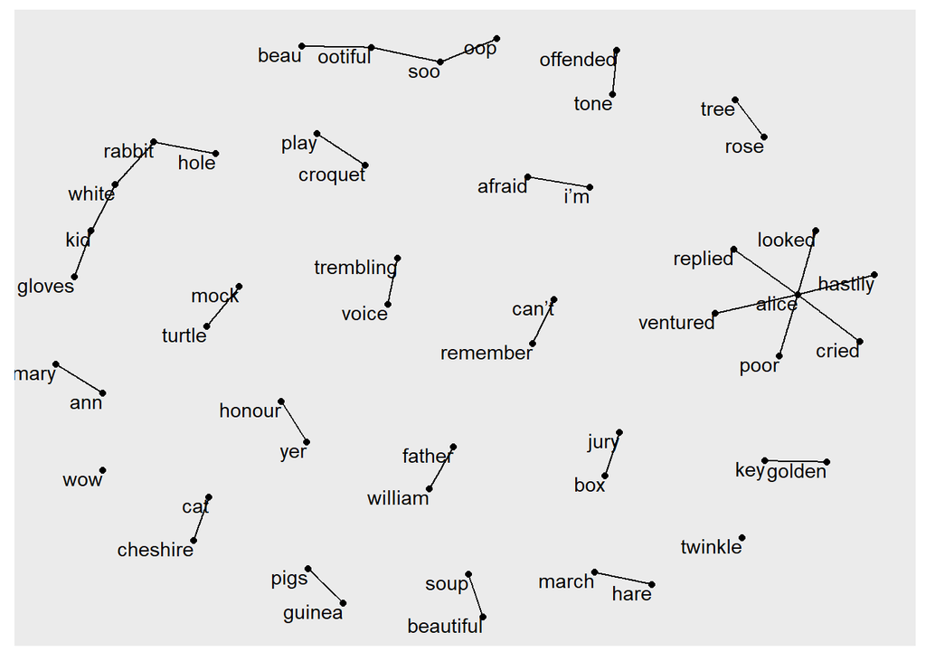

```r
set.seed(2023)

ggraph(alice_graph, layout = "fr") +
  geom_edge_link() +
  geom_node_point() +
  geom_node_text(aes(label = name),
                 vjust = 1, hjust = 1)
```

We get a sense of which words occur together, but the graph could definitely look prettier and it’s unclear which word occurs first: is it “rose tree” or “tree rose”, for example?

We’ll create an object called “a” that saves an arrow shape:

```r
a <- grid::arrow(type = "closed", length = unit(.15, "inches"))
```

This way, we can indicate how the words in the bigrams are ordered.

Nicer graph:

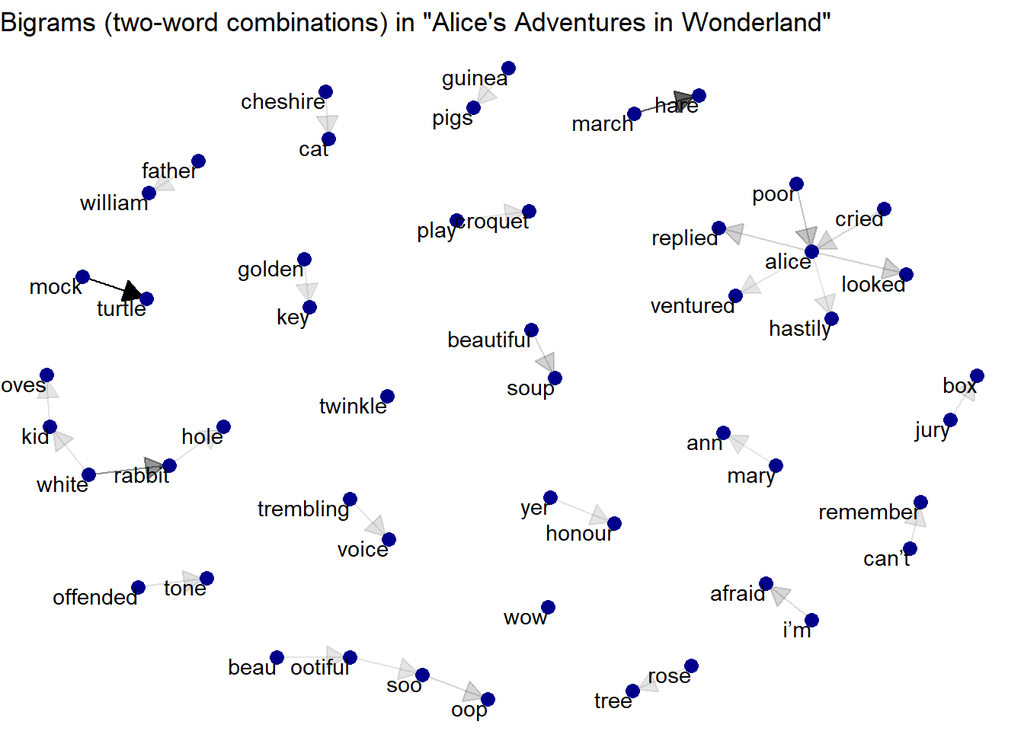

```r
ggraph(alice_graph, layout = "fr") +
  geom_edge_link(aes(edge_alpha = n), # the links are more transparent if the bigram is rare
                 show.legend = FALSE,
                 arrow = a, end_cap = circle(.03, 'inches')) + #adding the arrows, making sure they don't touch the node
  geom_node_point(color = "darkblue", size = 3) +
  geom_node_text(aes(label = name), vjust = 1, hjust = 1) +
  theme_void() +
  labs(title = 'Bigrams (two-word combinations) in "Alice\'s Adventures in Wonderland"')
```

## TRY IT

### Bigram network of Beyoncé lyrics

```r
beyonce <- read_csv('https://raw.githubusercontent.com/rfordatascience/tidytuesday/master/data/2020/2020-09-29/beyonce_lyrics.csv')
head(beyonce)
```

```
## # A tibble: 6 × 6
##   line                         song_id song_name artist_id artist_name song_line
##   <chr>                          <dbl> <chr>         <dbl> <chr>           <dbl>
## 1 If I ain't got nothing, I g…   50396 1+1             498 Beyoncé             1
## 2 If I ain't got something, I…   50396 1+1             498 Beyoncé             2
## 3 'Cause I got it with you       50396 1+1             498 Beyoncé             3
## 4 I don't know much about alg…   50396 1+1             498 Beyoncé             4
## 5 And it's me and you            50396 1+1             498 Beyoncé             5
## 6 That's all we'll have when …   50396 1+1             498 Beyoncé             6
```

Here are step-by-step tips: - remove the song “Halo Greek translation” - use `unnest_tokens()` to create a column with bigrams - remove any missing values (with `drop_na()`) - separate the bigrams into single words - remove stopwords - count how often each word 1 word 2 combination occurs in the data - make sure to only keep word combinations that occur more often than 15 times - use `graph_from_data_frame()` …then plot!

Additionally, you can create (or add to, if you completed the Taylor Swift exercise) a list of custom stopwords that often occur in songs (“uuh”, “oh”, etc.)

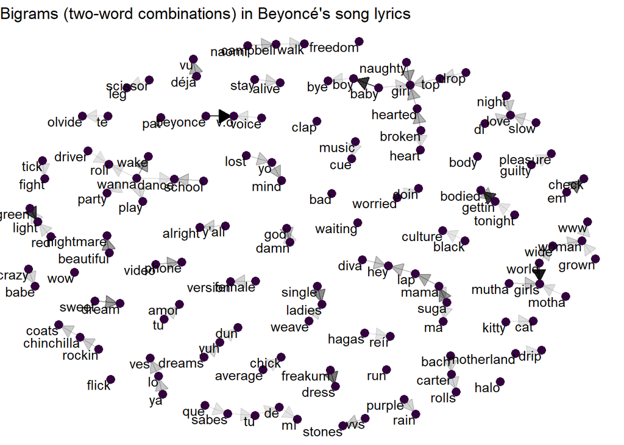

```r
custom_stop <- c("ooh", "ah", "na", "whoa", "uh", "ey", "ha", "eeh", "woah", "ohh", "yeah", "ohhh", "eh", "aah", "ahh")

beyonce_graph <- beyonce %>%
  filter(song_name != "Halo Greek translation") %>%
  unnest_tokens(bigram, line, token = "ngrams", n = 2) %>%
  drop_na(bigram) %>%
  separate(bigram, c("word1", "word2"), sep = " ") %>%
  filter(!word1 %in% stop_words$word &
           !word2 %in% stop_words$word &
           !word1 %in% custom_stop &
           !word2 %in% custom_stop) %>%
  count(word1, word2) %>% # we need the words separated for this graph
  filter(n > 15) %>%
  graph_from_data_frame()

a <- grid::arrow(type = "closed", length = unit(.15, "inches"))

ggraph(beyonce_graph, layout = "fr") +
  geom_edge_link(aes(edge_alpha = n), # the links are more transparent if the bigram is rare
                 show.legend = FALSE,
                 arrow = a, end_cap = circle(.03, 'inches')) + #adding the arrows, making sure they don't touch the node
  geom_node_point(color = "#34013f", size = 3) + # larger, purple nodes
  geom_node_text(aes(label = name), vjust = 1, hjust = 1) +
  theme_void() +
  labs(title = "Bigrams (two-word combinations) in Beyoncé's song lyrics")
```

# 3 Comparing the vocabulary of texts

Next, we’ll create two graphs to compare the vocabulary of our texts, focusing on Alice’s Adventures and Anderson’s Fairytales. The newly created comp_2 data frame contains only the words and their frequencies in the two texts in two separate columns.

## Creating a suitable data frame

```r
comp_2 <- fairytales_freq %>%
  filter(gutenberg_id == "Alice's Adventures in Wonderland"|gutenberg_id == "Hans Christian Anderson's Fairytales") %>%
  group_by(gutenberg_id) %>%
  mutate(proportion = n / sum(n)) %>% #creates proportion column (word frequency divided by overall frequency per author)
  select(-n) %>%
  pivot_wider(names_from = gutenberg_id,
              values_from = proportion)

comp_2
```

```
## # A tibble: 5,632 × 3
##    word     `Alice's Adventures in Wonderland` Hans Christian Anderson's Fairy…¹
##    <chr>                                 <dbl>                             <dbl>
##  1 alice                              0.0509                            NA
##  2 gerda                             NA                                  0.00655
##  3 tree                               0.00115                            0.00621
##  4 looked                             0.00574                            0.00552
##  5 shadow                            NA                                  0.00488
##  6 stood                              0.000892                           0.00488
##  7 princess                          NA                                  0.00483
##  8 shoes                              0.000892                           0.00465
##  9 boy                                0.000382                           0.00454
## 10 queen                              0.00969                            0.00195
## # ℹ 5,622 more rows
## # ℹ abbreviated name: ¹`Hans Christian Anderson's Fairytales`
```

## Creating a graph

Now, we can plot the words. Their placement depends on the word frequencies. Additionally, colour coding shows how different the frequencies are - darker items are more similar in terms of their frequencies, lighter-coloured ones more frequent in one text compared to the other. We’ll discuss the interpretation in more detail once we’ve created the threeway comparison.

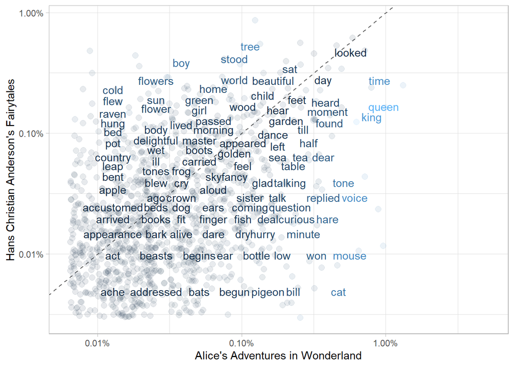

```r
ggplot(comp_2,
       aes(x = `Alice's Adventures in Wonderland`, y = `Hans Christian Anderson's Fairytales`,
           color = abs(`Alice's Adventures in Wonderland` - `Hans Christian Anderson's Fairytales`))) +
  geom_abline(color = "gray40", lty = 2) +
  geom_jitter(alpha = 0.1, size = 2.5, width = 0.3, height = 0.3) +
  geom_text(aes(label = word), check_overlap = TRUE, vjust = 1.5) +
  scale_x_log10(labels = percent_format()) +
  scale_y_log10(labels = percent_format()) +
  theme_light() +
  theme(legend.position="none") +
  labs(y = "Hans Christian Anderson's Fairytales", x = "Alice's Adventures in Wonderland")
```

#### TRY IT

Return to the lyrics we read in for the previous exercise:

```r
taylor_swift <- read_csv('https://raw.githubusercontent.com/rfordatascience/tidytuesday/master/data/2020/2020-09-29/taylor_swift_lyrics.csv')
beyonce <- read_csv('https://raw.githubusercontent.com/rfordatascience/tidytuesday/master/data/2020/2020-09-29/beyonce_lyrics.csv')
```

Our aim will be to compare words used in Taylor Swift’s lyrics to those used in Beyoncé’s lyrics - which words are used frequently by both artists, and which are used more by one or the other?

Steps: - for each data frame, we need to unnest tokens - and keep only the artist and word columns, making sure they’re in the same order and have the same names - then, we need to combine them into one data frame with `bind_rows()` - next, we should remove stopwords - then, we can calculate percentages for each artist separately - change the format of the data frame so that the percentages are in separate columns, one for each of the singers - we’re ready to plot!

Prep:

```r
beyonce <- beyonce %>%
  unnest_tokens(word, line, token = "words") %>%
  select(artist_name, word)

taylor_swift <- taylor_swift %>%
  unnest_tokens(word, Lyrics, token = "words") %>%
  rename(artist_name = Artist) %>%
  select(artist_name, word)

lyrics <- bind_rows(beyonce, taylor_swift) # make sure the format of the input data frames is exactly the same!
```

Wrangling:

```r
custom_stop <- c("ooh", "ah", "na", "whoa", "uh", "ey", "ha", "eeh", "woah", "ohh", "yeah", "ohhh", "eh", "aah", "ahh")

lyrics_comp <- lyrics %>%
  anti_join(stop_words) %>%
  filter(!word %in% custom_stop) %>%
  group_by(artist_name) %>%
  count(word) %>%
  mutate(proportion = n / sum(n)) %>%
  select(-n) %>%
  pivot_wider(names_from = artist_name,
              values_from = proportion)
```

Plot:

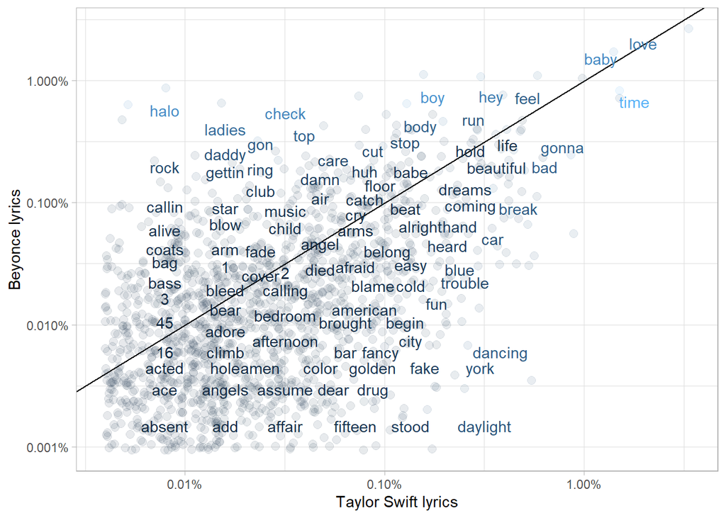

```r
ggplot(lyrics_comp) +
  aes(x = `Taylor Swift`, y = `Beyoncé`,
      colour = abs(`Taylor Swift` - `Beyoncé`)) +
  geom_abline() +
  geom_jitter(alpha = 0.1, size = 2.5, width = 0.3, height = 0.3) +
  geom_text(aes(label = word), check_overlap = TRUE, vjust = 1.5) +
  scale_x_log10(labels = percent_format()) +
  scale_y_log10(labels = percent_format()) +
  theme_light() +
  theme(legend.position="none") +
  labs(x = "Taylor Swift lyrics",
       y = "Beyonce lyrics")
```

Interpretation: - Words close to the line are used equally frequently by both artists (examples: beginning, bleed, filled, fit, arms, dance, hold, baby) - Words below the line are used more frequently by Taylor Swift (examples: daylight, undone, summer, add, absent, darling, fun) - Words above the line are used more frequenty by Beyoncé (examples: halo, ladies, daddy, rock, check, top, minute, care)

# 4 Word and document frequencies

## tf-idf

How can we quantify what a text/document is about? We could analyse the term frequency (tf) - how often does a term occur in a text/document. However, common words are the same in most texts, e.g. grammatical words like articles. A solution would be to instead analyse the inverse document frequency (idf) which lowers the importance of frequent words and raises the importance of rare words in documents. So it’s a measure of how important a word is to a text compared to how important it is in the collection of texts.

### The bind_tf_idf-function

- input: format needs to be one row per token (term), per document
- one column (here: word) contains the terms/tokens
- one column (here: gutenberg_id) contains the documents

```r
head(fairytales_freq)
```

```
## # A tibble: 6 × 3
##   gutenberg_id                     word       n
##   <fct>                            <chr>  <int>
## 1 Alice's Adventures in Wonderland alice    399
## 2 Grimm's Fairytales               king     368
## 3 Grimm's Fairytales               time     207
## 4 Grimm's Fairytales               day      192
## 5 Grimm's Fairytales               father   183
## 6 Grimm's Fairytales               home     180
```

To add the tf-idf score:

```r
fairytales_idf <- fairytales_freq %>%
  bind_tf_idf(word, gutenberg_id, n) # arguments: token, document, count

fairytales_idf %>%
  select(gutenberg_id, word, tf_idf) %>%
  arrange(desc(tf_idf))
```

```
## # A tibble: 11,096 × 3
##    gutenberg_id                         word      tf_idf
##    <fct>                                <chr>      <dbl>
##  1 Alice's Adventures in Wonderland     alice    0.0559
##  2 Alice's Adventures in Wonderland     mock     0.00798
##  3 Alice's Adventures in Wonderland     hatter   0.00784
##  4 Alice's Adventures in Wonderland     gryphon  0.00770
##  5 Alice's Adventures in Wonderland     rabbit   0.00742
##  6 Hans Christian Anderson's Fairytales gerda    0.00720
##  7 Alice's Adventures in Wonderland     duchess  0.00588
##  8 Alice's Adventures in Wonderland     dormouse 0.00560
##  9 Hans Christian Anderson's Fairytales shadow   0.00537
## 10 Hans Christian Anderson's Fairytales kay      0.00454
## # ℹ 11,086 more rows
```

interpretation: * low tf_idf if words appear in many books - high tf_idf if they occur in few books  
* helps us find characteristic words for documents  
* so unsurprisingly, in our data, the first hits with the highest tf_idf are character names

#### Characteristic words per book

Visualisation of the top 20 tf-idf words per book:

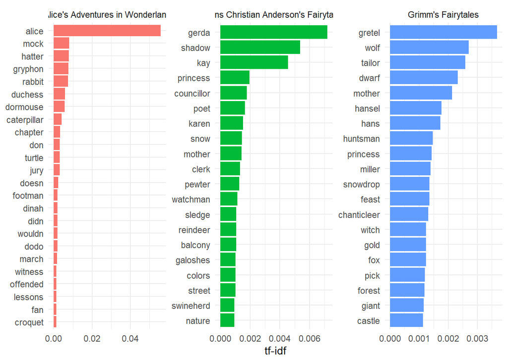

```r
fairytales_idf %>%
  group_by(gutenberg_id) %>%
  slice_max(order_by = tf_idf, n = 20) %>%
  ggplot(aes(x = reorder_within(word, tf_idf, gutenberg_id), y = tf_idf, fill = gutenberg_id)) +
  geom_col(show.legend = FALSE) +
  labs(x = NULL, y = "tf-idf") +
  facet_wrap(~gutenberg_id, scales = "free") +
  coord_flip() +
  scale_x_reordered() +
  theme_minimal()
```

#### Characteristic words per chapter

tf_idf can also be used to find characteristic words per chapter, or any other text unit. We’ll only use “Alice in Wonderland” as an example since it consists of several chapters.

We already created a data frame with information on which chapter each line came from:

```r
alice
```

```
## # A tibble: 3,351 × 2
##    text                                                                  chapter
##    <chr>                                                                 <fct>
##  1 "CHAPTER I."                                                          1
##  2 "Down the Rabbit-Hole"                                                1
##  3 ""                                                                    1
##  4 ""                                                                    1
##  5 "Alice was beginning to get very tired of sitting by her sister on t… 1
##  6 "bank, and of having nothing to do: once or twice she had peeped int… 1
##  7 "the book her sister was reading, but it had no pictures or"          1
##  8 "conversations in it, “and what is the use of a book,” thought Alice" 1
##  9 "“without pictures or conversations?”"                                1
## 10 ""                                                                    1
## # ℹ 3,341 more rows
```

To prepare this for the analysis:

```r
alice_freq <- alice %>%
  unnest_tokens(word, text) %>%
  anti_join(stop_words)
```

Now let’s calculate the tf-idf per chapter: * first step is to calculate the frequency for each word per chapter * then apply bind_tf_idf function * show words with the highest tf_idf

```r
alice_freq <- alice_freq %>%
  group_by(chapter) %>%
  count(word, sort = TRUE)

alice_freq
```

```
## # A tibble: 4,545 × 3
## # Groups:   chapter [12]
##    chapter word        n
##    <fct>   <chr>   <int>
##  1 7       alice      50
##  2 9       alice      47
##  3 6       alice      43
##  4 8       alice      39
##  5 5       alice      35
##  6 7       hatter     32
##  7 8       queen      31
##  8 10      gryphon    31
##  9 4       alice      30
## 10 10      alice      30
## # ℹ 4,535 more rows
```

```r
alice_idf <- alice_freq %>%
  bind_tf_idf(word, chapter, n)

alice_idf %>%
  select(chapter, word, tf_idf) %>%
  arrange(desc(tf_idf))
```

```
## # A tibble: 4,545 × 3
## # Groups:   chapter [12]
##    chapter word        tf_idf
##    <fct>   <chr>        <dbl>
##  1 7       dormouse    0.0639
##  2 7       hatter      0.0609
##  3 10      turtle      0.0565
##  4 5       caterpillar 0.0557
##  5 10      mock        0.0545
##  6 9       turtle      0.0509
##  7 9       mock        0.0490
##  8 5       pigeon      0.0479
##  9 10      gryphon     0.0478
## 10 11      hatter      0.0467
## # ℹ 4,535 more rows
```

Again, we can visualise the most characteristic words, this time per chapter:

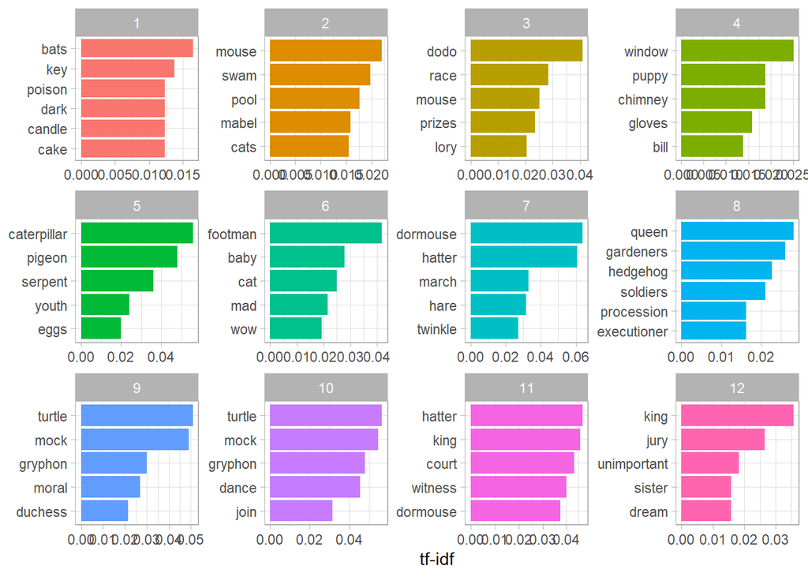

```r
alice_idf %>%
  group_by(chapter) %>%
  slice_max(order_by = tf_idf, n = 5) %>% # we get 6 or 7 words for some chapters because of ties in the tf_idf column
  ggplot(aes(reorder_within(word, tf_idf, chapter), tf_idf, fill = chapter)) +
  geom_col(show.legend = FALSE) +
  theme_light() +
  labs(x = NULL, y = "tf-idf") +
  facet_wrap(~ chapter, scales = "free") +
  coord_flip() +
  scale_x_reordered()
```

## TRY IT

### TF-IDF with n-grams

Instead of looking at characteristic words per document, we can analyse characteristic bigrams or n-grams per document. Let’s do this for the different chapters.

Start with the alice_bigrams_stop data we created earlier and follow these steps: - count how often each bigram appears in each chapter - then, use `bind_tf_idf` - finally, recreate the plot we made above (but filter to the top 3 bigrams per chapter)

```r
(alice_bigram_tfidf <- alice_bigrams_stop %>%
  count(chapter, bigram) %>%
  bind_tf_idf(bigram, chapter, n))
```

```
## # A tibble: 1,429 × 6
##    chapter bigram                  n      tf   idf tf_idf
##    <fct>   <chr>               <int>   <dbl> <dbl>  <dbl>
##  1 1       air i’m                 1 0.00917  2.48 0.0228
##  2 1       alice started           1 0.00917  2.48 0.0228
##  3 1       alice ventured          1 0.00917  1.39 0.0127
##  4 1       apple roast             1 0.00917  2.48 0.0228
##  5 1       bats eat                1 0.00917  2.48 0.0228
##  6 1       beautifully marked      1 0.00917  2.48 0.0228
##  7 1       beautifully printed     1 0.00917  2.48 0.0228
##  8 1       bit hurt                1 0.00917  2.48 0.0228
##  9 1       book shelves            1 0.00917  2.48 0.0228
## 10 1       bottle marked           1 0.00917  2.48 0.0228
## # ℹ 1,419 more rows
```

```r
alice_bigram_tfidf %>%
  arrange(desc(tf_idf))
```

```
## # A tibble: 1,429 × 6
##    chapter bigram              n     tf   idf tf_idf
##    <fct>   <chr>           <int>  <dbl> <dbl>  <dbl>
##  1 10      mock turtle        26 0.162   1.79 0.291
##  2 9       mock turtle        24 0.144   1.79 0.257
##  3 7       march hare         21 0.127   1.10 0.140
##  4 10      beautiful soup      8 0.05    2.48 0.124
##  5 10      soo oop             7 0.0438  2.48 0.109
##  6 7       twinkle twinkle     5 0.0303  2.48 0.0753
##  7 6       wow wow             4 0.0301  2.48 0.0747
##  8 3       caucus race         3 0.0297  2.48 0.0738
##  9 3       crowded round       3 0.0297  2.48 0.0738
## 10 1       cats eat            3 0.0275  2.48 0.0684
## # ℹ 1,419 more rows
```

The tf_idf column shows us characteristic words for each chapter. The mock turtle, for example, makes appearances in chapters 9 and 10 while the march hare can be found in chapter 7.

*Plot*

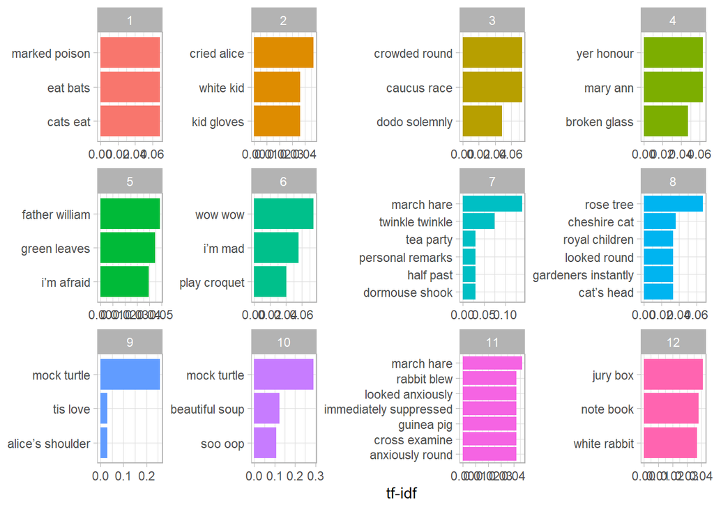

```r
alice_bigram_tfidf %>%
  group_by(chapter) %>%
  slice_max(order_by = tf_idf, n = 3) %>%
  ggplot(aes(y = reorder_within(bigram, tf_idf, chapter), x = tf_idf, fill = chapter)) +
  geom_col(show.legend = FALSE) +
  theme_light() +
  labs(y = NULL, x = "tf-idf") +
  facet_wrap(~ chapter, scales = "free") +
  scale_y_reordered()
```

### Characteristic bigrams in Taylor Swift’s albums

Using Taylor Swift’s lyrics, recreate the tf-idf bar graph we made earlier. We’re interested in characteristic bigrams per album.

```r
taylor_swift <- read_csv('https://raw.githubusercontent.com/rfordatascience/tidytuesday/master/data/2020/2020-09-29/taylor_swift_lyrics.csv')
head(taylor_swift)
```

```
## # A tibble: 6 × 4
##   Artist       Album        Title                  Lyrics
##   <chr>        <chr>        <chr>                  <chr>
## 1 Taylor Swift Taylor Swift Tim McGraw             "He said the way my blue eye…
## 2 Taylor Swift Taylor Swift Picture to Burn        "State the obvious, I didn't…
## 3 Taylor Swift Taylor Swift Teardrops on my Guitar "Drew looks at me,\nI fake a…
## 4 Taylor Swift Taylor Swift A Place in This World  "I don't know what I want, s…
## 5 Taylor Swift Taylor Swift Cold As You            "You have a way of coming ea…
## 6 Taylor Swift Taylor Swift The Outside            "I didn't know what I would …
```

The steps you need to get there are: - use `unnest_tokens()` to extract bigrams from the `Lyrics` column - `separate()` the bigrams into single words - remove stopwords (making sure to remove them if they’re the first or the second word in the bigram) - count how often each bigram appears per album - use `bind_tf_idf()`

Plot the five bigrams with the highest `tf_idf` per album. As a bonus, create a custom stopword list of words like “uh” and “ah” that occur in the lyrics and remove those, too. The bar graph helps you identify them.

```r
custom_stop <- c("ooh", "ah", "na", "whoa", "uh", "ey", "ha", "eeh", "woah", "ohh", "yeah", "ohhh", "eh", "aah", "ahh")

(taylor_tfidf <- taylor_swift %>%
  unnest_tokens(bigram, Lyrics, token = "ngrams", n = 2) %>%
  separate(bigram, c("word1", "word2"), sep = " ", remove = FALSE) %>%
  filter(!word1 %in% stop_words$word &
           !word2 %in% stop_words$word &
           !word1 %in% custom_stop &
           !word2 %in% custom_stop) %>%
  count(Album, bigram) %>%
  bind_tf_idf(bigram, Album, n))
```

```
## # A tibble: 1,745 × 6
##    Album bigram               n      tf   idf  tf_idf
##    <chr> <chr>            <int>   <dbl> <dbl>   <dbl>
##  1 1989  2 a.m                3 0.00620  2.08 0.0129
##  2 1989  airplanes flying     1 0.00207  2.08 0.00430
##  3 1989  anymore hung         1 0.00207  2.08 0.00430
##  4 1989  apartment floors     1 0.00207  2.08 0.00430
##  5 1989  arms twisting        2 0.00413  2.08 0.00859
##  6 1989  babe red             4 0.00826  2.08 0.0172
##  7 1989  baby baby            1 0.00207  1.39 0.00286
##  8 1989  bad blood           15 0.0310   2.08 0.0644
##  9 1989  bad guys             1 0.00207  1.39 0.00286
## 10 1989  bad sign             2 0.00413  2.08 0.00859
## # ℹ 1,735 more rows
```

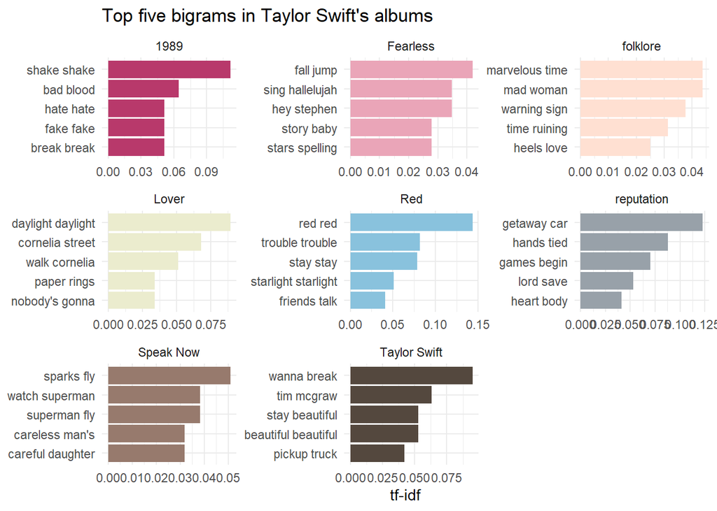

```r
taylor_tfidf %>%
  group_by(Album) %>%
  slice_max(tf_idf, n = 5, with_ties = FALSE) %>%
  ungroup() %>%
  ggplot() +
  aes(x = tf_idf,
      y = fct_reorder(bigram, tf_idf),
      fill = Album) +
  geom_bar(stat = "identity") +
  facet_wrap(~ Album, scales = "free") +
  labs(x = "tf-idf",
       y = NULL,
       title = "Top five bigrams in Taylor Swift's albums") +
  theme_minimal() +
  theme(legend.position = "none") +
  tayloRswift::scale_fill_taylor(palette = "lover")
```

# 5 Sentiment analysis

## Sentiment analysis based on single words

### Animal Crossing Data

Animal Crossing is a 2020 “sandbox” game, where your character lives on an island with a variety of different animal characters and collects resources to progress and upgrade the island. It has had mixed reviews: either it is the best game ever, or boring and pointless. It has also been criticized for the fact that you can only have one save game per console (“forcing” families/couples to buy extra consoles to avoid fights over island decor..)

“user_reviews” includes the date of a review posting, the user_name of the writer, the grade they give the game (0-10), and the text they wrote.

```r
user_reviews_raw <- readr::read_tsv('https://raw.githubusercontent.com/rfordatascience/tidytuesday/master/data/2020/2020-05-05/user_reviews.tsv') #download from tidytuesday github
head(user_reviews_raw)
```

```
## # A tibble: 6 × 4
##   grade user_name    text                                             date
##   <dbl> <chr>        <chr>                                            <date>
## 1     4 mds27272     My gf started playing before me. No option to c… 2020-03-20
## 2     5 lolo2178     While the game itself is great, really relaxing… 2020-03-20
## 3     0 Roachant     My wife and I were looking forward to playing t… 2020-03-20
## 4     0 Houndf       We need equal values and opportunities for all … 2020-03-20
## 5     0 ProfessorFox BEWARE!  If you have multiple people in your ho… 2020-03-20
## 6     0 tb726        The limitation of one island per Switch (not pe… 2020-03-20
```

### Preprocessing

- unnesting tokens (words)
- removing stopwords, including the two custom words “nintendo” and “switch” Note - it’s not always necessary to remove all stop words for sentiment analysis – if a word has no emotional/sentiment-based meaning, it will just receive no score. But can be useful for misclassified words.

```r
more_stop_words <- tibble(word = c("nintendo", "switch"))

user_reviews <- user_reviews_raw %>%
  unnest_tokens(word, text) %>%
  anti_join(stop_words) %>%
  anti_join(more_stop_words)
head(user_reviews)
```

```
## # A tibble: 6 × 4
##   grade user_name date       word
##   <dbl> <chr>     <date>     <chr>
## 1     4 mds27272  2020-03-20 gf
## 2     4 mds27272  2020-03-20 started
## 3     4 mds27272  2020-03-20 playing
## 4     4 mds27272  2020-03-20 option
## 5     4 mds27272  2020-03-20 create
## 6     4 mds27272  2020-03-20 island
```

### Sentiment analysis by word

#### bing

- Binary: positive/negative

```r
head(get_sentiments("bing"))
```

```
## # A tibble: 6 × 2
##   word       sentiment
##   <chr>      <chr>
## 1 2-faces    negative
## 2 abnormal   negative
## 3 abolish    negative
## 4 abominable negative
## 5 abominably negative
## 6 abominate  negative
```

Inner join to get a sentiment for each word:

```r
user_reviews %>%
  inner_join(get_sentiments("bing")) %>%
  head()
```

```
## # A tibble: 6 × 5
##   grade user_name date       word         sentiment
##   <dbl> <chr>     <date>     <chr>        <chr>
## 1     4 mds27272  2020-03-20 sucks        negative
## 2     4 mds27272  2020-03-20 miss         negative
## 3     4 mds27272  2020-03-20 terrible     negative
## 4     4 mds27272  2020-03-20 unacceptable negative
## 5     5 lolo2178  2020-03-20 gorgeous     positive
## 6     5 lolo2178  2020-03-20 ignore       negative
```

-> note that this removes any words that are not in this sentiment dictionary!

```r
user_reviews %>%
  inner_join(get_sentiments("bing"))%>%
  count(sentiment)
```

```
## # A tibble: 2 × 2
##   sentiment     n
##   <chr>     <int>
## 1 negative  10699
## 2 positive   8406
```

Most common positive/negative words? Count by word and sentiment

```r
user_reviews %>%
  inner_join(get_sentiments("bing")) %>%
  group_by(sentiment) %>%
  count(word, sort = TRUE) %>%
  slice_max(order_by = n, n = 5)
```

```
## # A tibble: 10 × 3
## # Groups:   sentiment [2]
##    sentiment word             n
##    <chr>     <chr>        <int>
##  1 negative  bad            316
##  2 negative  limited        257
##  3 negative  issue          246
##  4 negative  ridiculous     199
##  5 negative  disappointed   190
##  6 positive  fun            760
##  7 positive  progress       556
##  8 positive  enjoy          405
##  9 positive  love           403
## 10 positive  amazing        304
```

Each reviewer’s sentiment score: (Note: we retain “grade” in the count command to keep this column for later)

```r
user_reviews %>%
  inner_join(get_sentiments("bing")) %>%
  count(user_name, grade, sentiment) %>%
  head()
```

```
## # A tibble: 6 × 4
##   user_name   grade sentiment     n
##   <chr>       <dbl> <chr>     <int>
## 1 000anon2759     0 negative      2
## 2 11_11           0 negative      5
## 3 11_11           0 positive      4
## 4 12hwilso        0 negative      1
## 5 12hwilso        0 positive      1
## 6 1mooey         10 negative      1
```

Create columns for negative and positive counts, then calculate the total_score column (& save)

```r
(user_sentiments_bing <- user_reviews %>%
  inner_join(get_sentiments("bing")) %>%
  count(user_name, grade, sentiment) %>%
  pivot_wider(names_from = "sentiment",
              values_from = n,
              values_fill = 0) %>%
  mutate(total_score = positive - negative))
```

```
## # A tibble: 2,712 × 5
##    user_name    grade negative positive total_score
##    <chr>        <dbl>    <int>    <int>       <int>
##  1 000anon2759      0        2        0          -2
##  2 11_11            0        5        4          -1
##  3 12hwilso         0        1        1           0
##  4 1mooey          10        1        3           2
##  5 3nd3r02          2        4        9           5
##  6 425_Flex         0        8        0          -8
##  7 486eHyMy         0        0        1           1
##  8 4Plants         10        2        2           0
##  9 5DExperience     0        5        3          -2
## 10 68Dube           4        3        0          -3
## # ℹ 2,702 more rows
```

Look at the range of the scores

```r
user_sentiments_bing %>%
  summarize(max(total_score), min(total_score))
```

```
## # A tibble: 1 × 2
##   `max(total_score)` `min(total_score)`
##                <int>              <int>
## 1                 23                -37
```

Let’s see if there seems to be a relationship between the sentiment of each review and the grade the reviewer gave:

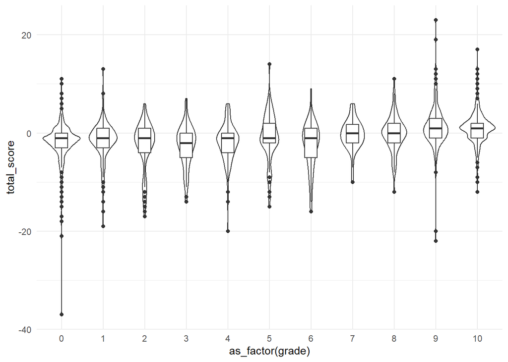

```r
ggplot(user_sentiments_bing) +
  aes(x = as_factor(grade), y = total_score) +
  geom_violin() +
  geom_boxplot(width = 0.3) +
  theme_minimal()
```

-> reviews with higher grades seem to be very slightly more positive than those with lower grades, but there is no clear trend

#### AFINN

- Scale: -5 (very negative) to 5 (very positive)

```r
head(get_sentiments("afinn"), n = 20)
```

```
## # A tibble: 20 × 2
##    word       value
##    <chr>      <dbl>
##  1 abandon       -2
##  2 abandoned     -2
##  3 abandons      -2
##  4 abducted      -2
##  5 abduction     -2
##  6 abductions    -2
##  7 abhor         -3
##  8 abhorred      -3
##  9 abhorrent     -3
## 10 abhors        -3
## 11 abilities      2
## 12 ability        2
## 13 aboard         1
## 14 absentee      -1
## 15 absentees     -1
## 16 absolve        2
## 17 absolved       2
## 18 absolves       2
## 19 absolving      2
## 20 absorbed       1
```

Join to reviews and take a look

```r
user_reviews %>%
  inner_join(get_sentiments("afinn")) %>%
  head()
```

```
## # A tibble: 6 × 5
##   grade user_name date       word         value
##   <dbl> <chr>     <date>     <chr>        <dbl>
## 1     4 mds27272  2020-03-20 sucks           -3
## 2     4 mds27272  2020-03-20 miss            -2
## 3     4 mds27272  2020-03-20 terrible        -3
## 4     4 mds27272  2020-03-20 unacceptable    -2
## 5     5 lolo2178  2020-03-20 ignore          -1
## 6     5 lolo2178  2020-03-20 ruins           -2
```

Sum up one total per review (& save)

```r
(user_sentiments_afinn <- user_reviews %>%
  group_by(user_name, grade) %>% #retain grade for use later
  inner_join(get_sentiments("afinn")) %>%
  summarize(total_score = sum(value)) %>%
  ungroup())
```

```
## # A tibble: 2,723 × 3
##    user_name    grade total_score
##    <chr>        <dbl>       <dbl>
##  1 000PLAYER000    10          -1
##  2 000anon2759      0          -7
##  3 11_11            0          15
##  4 12hwilso         0           1
##  5 1mooey          10          10
##  6 24ths            0           1
##  7 3nd3r02          2          13
##  8 425_Flex         0         -19
##  9 486eHyMy         0           4
## 10 4Plants         10           7
## # ℹ 2,713 more rows
```

Look at the range of the scores

```r
user_sentiments_afinn %>%
  summarize(max(total_score), min(total_score))
```

```
## # A tibble: 1 × 2
##   `max(total_score)` `min(total_score)`
##                <dbl>              <dbl>
## 1                 87                -37
```

Graph it:

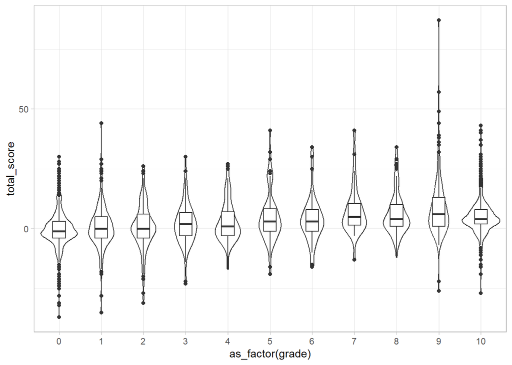

```r
ggplot(user_sentiments_afinn) +
  aes(x=as_factor(grade), y=total_score) +
  geom_violin() +
  geom_boxplot(width = 0.3) +
  theme_light()
```

What’s going on with the very negative sentiment scores for some positive reviews? Let’s join the text back to the sentiment scores and take a look:

```r
user_sentiments_afinn <- left_join(user_sentiments_afinn, user_reviews_raw)
user_sentiments_afinn %>%
  filter(grade > 8 & total_score < 0) %>%
  select(grade, total_score, text) %>%
  arrange(total_score)
```

```
## # A tibble: 148 × 3
##    grade total_score text
##    <dbl>       <dbl> <chr>
##  1    10         -27 This is the best game stop review bombing it This is the b…
##  2     9         -26 I do love this game, very much, but there are a LOT of clu…
##  3     9         -22 I'm going to start this review by saying Animal Crossing N…
##  4    10         -19 What's wrong with people here? All this outrage for the 1 …
##  5    10         -16 I've played Nintendo since the NES console days and I can …
##  6    10         -15 Most reviews here that are low, are review bombs due to th…
##  7    10         -13 I dont think that one switch for one island is bad or good…
##  8    10         -13 Anyone rating this game a 2 or lower is an actual baby. Ga…
##  9    10         -13 I usually don't write reviews to fight other people's revi…
## 10    10         -11 I mean, I kind of understand why most of the negative revi…
## # ℹ 138 more rows
```

Turns out these reviewers give 10 points to offset the (as they see it) unjustly low reviews while making fun of people who give 0 points or rate the game before it has come out.

Reversely, why positive scores with low grades?

```r
user_sentiments_afinn %>%
  filter(grade < 3 & total_score > 20) %>%
  select(grade, total_score, text) %>%
  arrange(desc(total_score))
```

```
## # A tibble: 21 × 3
##    grade total_score text
##    <dbl>       <dbl> <chr>
##  1     1          44 My family and I (mom and two daughters) were really hyped …
##  2     0          30 Ive been excited about New horizons for a long time. I was…
##  3     1          29 Where to start...I'd never played an animal crossing game,…
##  4     0          28 Unfortunately, I cannot recommend this game in good faith.…
##  5     1          27 EDIT:Some people just refuse to understand the situation s…
##  6     0          27 I loved this game at first. My girlfriend turned me onto i…
##  7     2          26 My son and daughter have always lovedAnimal Crossing. They…
##  8     1          25 My girlfriend and I were so excited about this game. She g…
##  9     0          25 to start, this game is terrific. for a single person playi…
## 10     2          24 I absolutely love Animal Crossing and have played every si…
## # ℹ 11 more rows
```

These reviewers tend to say that they initially liked the game until they realised that only one person could play it.

#### nrc

```r
head(get_sentiments("nrc"))
```

```
## # A tibble: 6 × 2
##   word      sentiment
##   <chr>     <chr>
## 1 abacus    trust
## 2 abandon   fear
## 3 abandon   negative
## 4 abandon   sadness
## 5 abandoned anger
## 6 abandoned fear
```

## Sentiment analysis for sentences

So far, we’ve used a dictionary lookup to add sentiments for each individual word. This approach can run into problems. For example, “happy” would always receive a positive score, even though depending on the context (e.g. “not happy at all”) that might not be appropriate. Next, we’ll calculate sentiment scores by sentence, using the [sentimentr package](https://cran.r-project.org/web/packages/sentimentr/readme/README.html). This package also considers things like negation (“not happy”) and amplifiers (“really happy” is more positive than just “happy”) as well as deamplifiers (e.g. “barely”) and adversative conjunctions (e.g. “but”) when calculating sentiment scores.

You can run these lines of code to see the items that are considered negators, amplifiers, deamplifiers, and adversative conjunctions.

```r
lexicon::hash_valence_shifters[y==1] # negators
```

```
##             x y
##  1:     ain't 1
##  2:      aint 1
##  3:    aren't 1
##  4:     arent 1
##  5:     can't 1
##  6:    cannot 1
##  7:      cant 1
##  8:  couldn't 1
##  9:   couldnt 1
## 10:   daren't 1
## 11:    darent 1
## 12:    didn't 1
## 13:     didnt 1
## 14:   doesn't 1
```

[output cut: 39 more lines]

```r
lexicon::hash_valence_shifters[y==2] # amplifiers
```

```
##                 x y
##  1:    absolutely 2
##  2:         acute 2
##  3:       acutely 2
##  4:       certain 2
##  5:     certainly 2
##  6:      colossal 2
##  7:    colossally 2
##  8:  considerably 2
##  9:     decidedly 2
## 10:          deep 2
## 11:        deeply 2
## 12:      definite 2
## 13:    definitely 2
## 14:      enormous 2
```

[output cut: 44 more lines]

```r
lexicon::hash_valence_shifters[y==3] # deamplifiers
```

```
##                x y
##  1:       almost 3
##  2:       barely 3
##  3:      faintly 3
##  4:          few 3
##  5:       hardly 3
##  6:   incredibly 3
##  7:      kind of 3
##  8:        kinda 3
##  9:        least 3
## 10:       little 3
## 11:         only 3
## 12:       partly 3
## 13:       rarely 3
## 14:       seldom 3
## 15:     slightly 3
## 16:     somewhat 3
## 17:      sort of 3
## 18:        sorta 3
## 19:     sparsely 3
## 20: sporadically 3
## 21:     very few 3
## 22:  very little 3
##                x y
```

```r
lexicon::hash_valence_shifters[y==4] # adversative conjunctions
```

```
##                   x y
## 1:         although 4
## 2:              but 4
## 3: despite all that 4
## 4: despite all this 4
## 5:     despite that 4
## 6:     despite this 4
## 7:          however 4
## 8:  that being said 4
## 9:          whereas 4
```

Let’s look at a simple example to compare the two approaches:

```r
examples <- data.frame(
  id = c("1", "2"),
  text = c("I was very happy.", "She was not happy.")
)

sentiment(get_sentences(examples$text))
```

```
##    element_id sentence_id word_count sentiment
## 1:          1           1          4     0.675
## 2:          2           1          4    -0.375
```

```r
examples %>%
  unnest_tokens(word, text) %>%
  inner_join(get_sentiments("bing"))
```

```
##   id  word sentiment
## 1  1 happy  positive
## 2  2 happy  positive
```

## Polarity

### …by entire texts

First, we’ll calculate an average sentiment score for each of the texts (i.e. entire plays) in our Shakespeare data. Be warned - since this is a lot of data, this will take a little while…

```r
shakes_sentiments <- shakes %>%
    mutate(sents = get_sentences(text)) %$% # note the different pipe symbol! We need to use this because the following function does not take the dataframe as the first argument
    sentiment_by(sents, doc_id) # this would also work for chapters or other units of text
```

#### Plotting

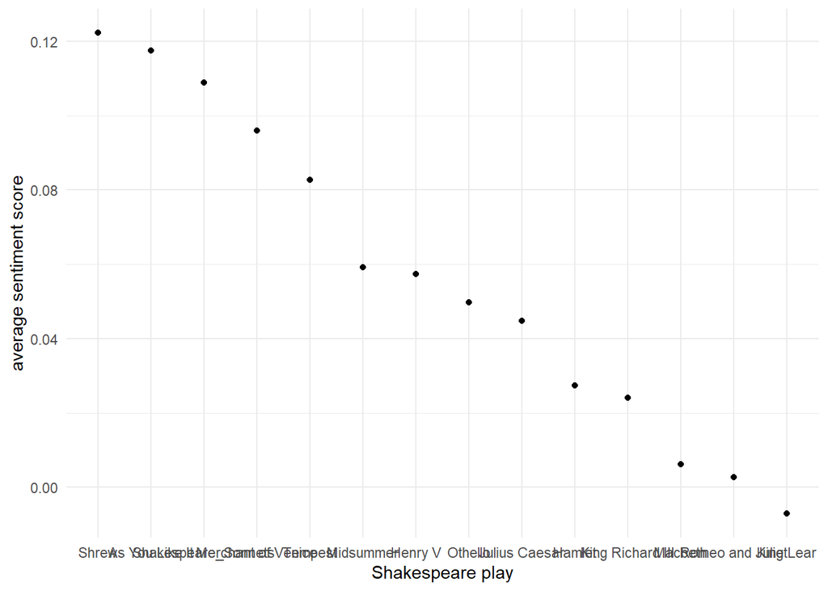

```r
ggplot(shakes_sentiments) +
  aes(x = reorder(doc_id, -ave_sentiment), y = ave_sentiment) +
  geom_point() +
  labs(x = "Shakespeare play", y = "average sentiment score") +
  theme_minimal()
```

Adding information on the kinds of plays and recreating the plot:

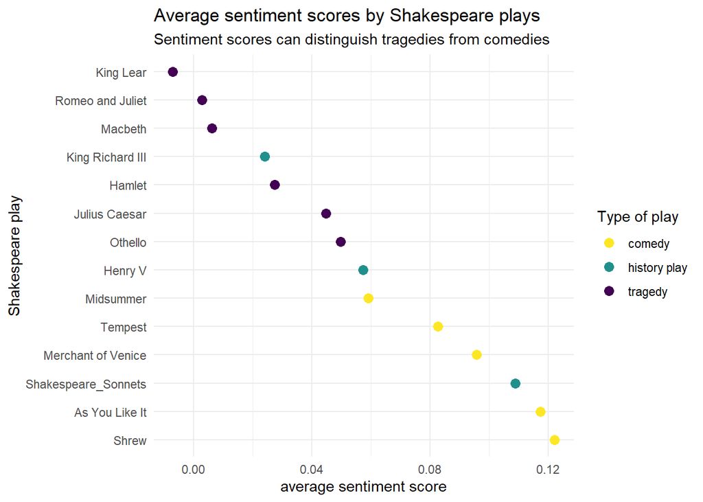

```r
shakes_sentiments <- shakes_sentiments %>%
  mutate(type_of_play = case_when(
    doc_id %in% c("Midsummer", "Tempest", "Merchant of Venice", "As You Like It", "Shrew") ~ "comedy",
    doc_id %in% c("King Lear", "Romeo and Juliet", "Macbeth", "Hamlet", "Julius Caesar", "Othello") ~ "tragedy",
    .default = "history play"
  ))

ggplot(shakes_sentiments) +
  aes(y = reorder(doc_id, -ave_sentiment), x = ave_sentiment) +
  geom_point(aes(colour = type_of_play), size = 3) +
  theme_minimal() +
  labs(y = "Shakespeare play",
       x = "average sentiment score",
       title = "Average sentiment scores by Shakespeare plays",
       subtitle = "Sentiment scores can distinguish tragedies from comedies",
       colour = "Type of play") +
  scale_colour_viridis(discrete = TRUE, direction = -1)
```

So we can see that the sentiment scores accurately distinguish the comedies and tragedies, with the comedies receiving higher sentiment scores.

### …by sentence

We’ll break the texts up into individual sentences and calculate the sentiment score for each individual sentence.

```r
shakes_sentences <- shakes %>%
  mutate(text = str_remove_all(text, "\\n")) %>% # for these texts, R represents line breaks as \n, which we need to delete because they mess with the get_sentences function
  get_sentences() %>%
  sentiment()

shakes_sentences
```

```
##                doc_id
##     1: As You Like It
##     2: As You Like It
##     3: As You Like It
##     4: As You Like It
##     5: As You Like It
##    ---
## 26368:        Tempest
## 26369:        Tempest
## 26370:        Tempest
## 26371:        Tempest
## 26372:        Tempest
##                                                                                                                                                                                                                                                                                                          …
##     1:                                                                                                                                                                                                                                 AS YOU LIKE ITby William ShakespeareSCENE:OLIVER'S house; FREDERIC…
##     2:                                                                                                                                                                                                                                                                          SCENE I.Orchard of OLIVER…
```

[output cut: 21 more lines]

#### Plotting

Now, we’ll plot the sentiment scores per sentence separately for each play.

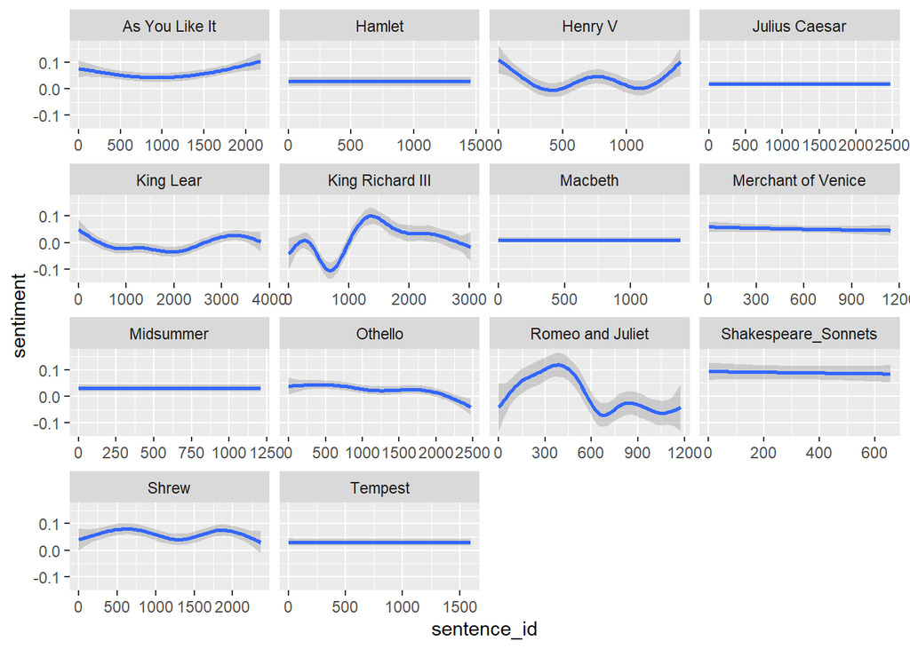

```r
ggplot(shakes_sentences) +
  aes(sentence_id, sentiment) +
  geom_smooth() +
  facet_wrap(~doc_id, scales = "free_x")
```

Let’s colour-code the plots by type of play:

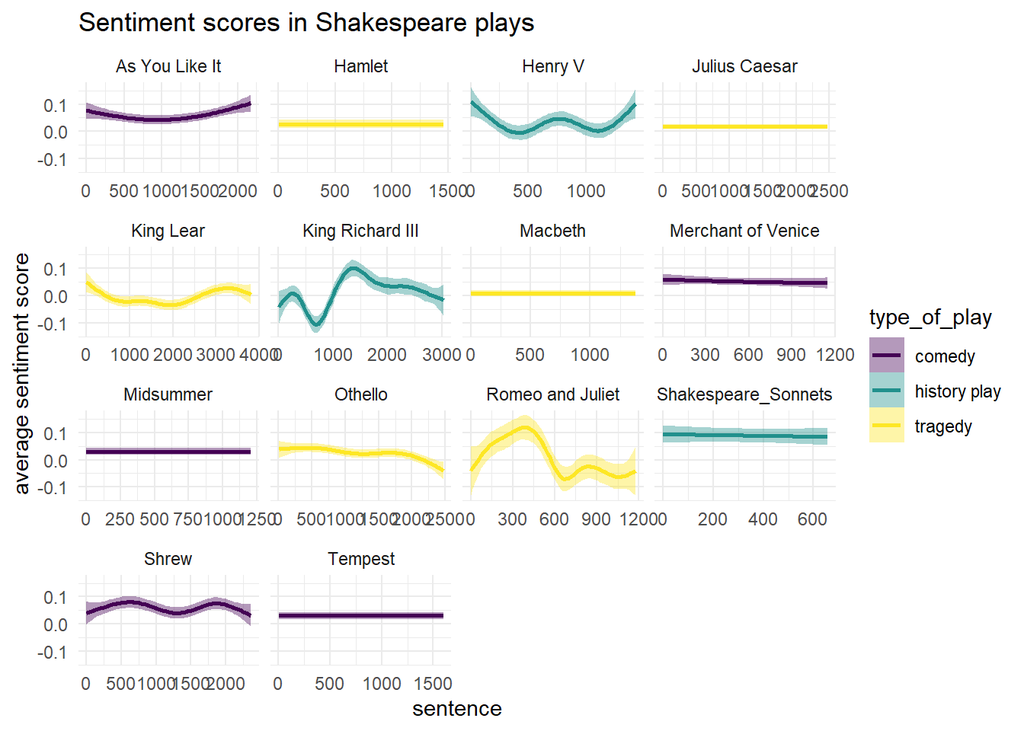

```r
shakes_sentences <- shakes_sentences %>%
  mutate(type_of_play = case_when(
    doc_id %in% c("Midsummer", "Tempest", "Merchant of Venice", "As You Like It", "Shrew") ~ "comedy",
    doc_id %in% c("King Lear", "Romeo and Juliet", "Macbeth", "Hamlet", "Julius Caesar", "Othello") ~ "tragedy",
    .default = "history play"
  ))

ggplot(shakes_sentences) +
  aes(sentence_id, sentiment, fill = type_of_play, color = type_of_play) +
  scale_fill_viridis(discrete=TRUE) +
  scale_color_viridis(discrete = TRUE) +
  geom_smooth() +
  facet_wrap(~doc_id, scales = "free_x") +
  labs(x = "sentence", y = "average sentiment score",
       title = "Sentiment scores in Shakespeare plays") +
  theme_minimal()
```

Plots like these can help trace sentiments throughout a text - but note that these sentiment dictionaries are still limited by the data they contain (mostly modern English, which is why some of these lines look very flat and likely don’t represent the actual sentiments in these plays).

### …by chapter and sentences

For this next part, we’ll use *Alice’s Adventures in Wonderland*. Since the gutenbergr package preserves the line structure of the original text, we need to first paste the lines to form a coherent text. Otherwise, the get_sentences function won’t work properly.

```r
alice <- alice %>%
  group_by(chapter) %>%
  summarise(text_complete = paste(text, collapse=" ")) %>%
  ungroup()

alice
```

```
## # A tibble: 12 × 2
##    chapter text_complete
##    <fct>   <chr>
##  1 1       "CHAPTER I. Down the Rabbit-Hole   Alice was beginning to get very t…
##  2 2       "CHAPTER II. The Pool of Tears   “Curiouser and curiouser!” cried Al…
##  3 3       "CHAPTER III. A Caucus-Race and a Long Tale   They were indeed a que…
##  4 4       "CHAPTER IV. The Rabbit Sends in a Little Bill   It was the White Ra…
##  5 5       "CHAPTER V. Advice from a Caterpillar   The Caterpillar and Alice lo…
##  6 6       "CHAPTER VI. Pig and Pepper   For a minute or two she stood looking …
##  7 7       "CHAPTER VII. A Mad Tea-Party   There was a table set out under a tr…
##  8 8       "CHAPTER VIII. The Queen’s Croquet-Ground   A large rose-tree stood …
##  9 9       "CHAPTER IX. The Mock Turtle’s Story   “You can’t think how glad I a…
## 10 10      "CHAPTER X. The Lobster Quadrille   The Mock Turtle sighed deeply, a…
## 11 11      "CHAPTER XI. Who Stole the Tarts?   The King and Queen of Hearts wer…
## 12 12      "CHAPTER XII. Alice’s Evidence   “Here!” cried Alice, quite forgetti…
```

Let’s now get sentiment scores for each sentence:

```r
alice_sentences <- alice %>%
  get_sentences() %>%
  sentiment()
```

#### Plotting

…and plot their development per chapter:

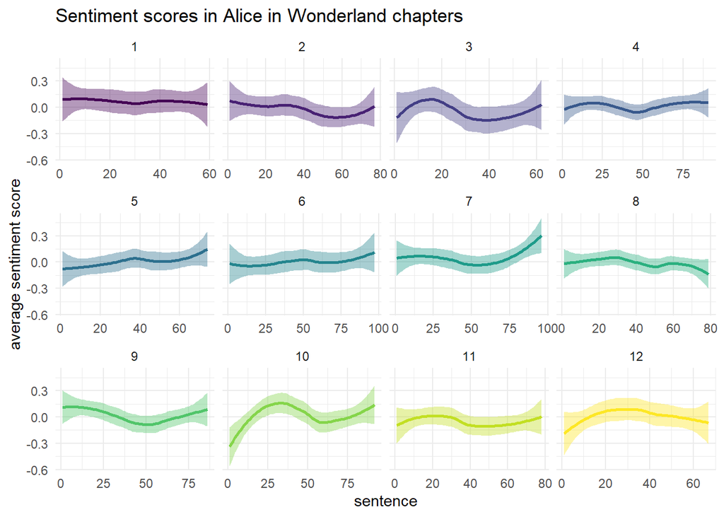

```r
ggplot(alice_sentences) +
  aes(sentence_id, sentiment, colour = chapter, fill = chapter) +
  geom_smooth(show.legend = FALSE) +
  facet_wrap(~chapter, scales = "free_x") +
  labs(x = "sentence",
       y = "average sentiment score",
       title = "Sentiment scores in Alice in Wonderland chapters") +
  theme_minimal() +
  scale_colour_viridis(discrete = TRUE) +
  scale_fill_viridis(discrete = TRUE)
```

## Emotions

We’ve focused on polarity (positive - negative) per sentences, but the sentimentr package also provides many other interesting functions. Here are some we won’t have time to go into today:  
- find and count instances of profanity - replace emojis and internet slang/abbreviations with their text equivalents - create your own sentiment dictionary - find emotions instead of sentiment (like the nrc dictionary - positive, negative, anger, anticipation, disgust, fear, joy, sadness, surprise)

See the documentation here: https://cran.r-project.org/web/packages/sentimentr/sentimentr.pdf)

## TRY IT

Try to use sentimentr, for example go back to the song lyrics data: - To get sentence-based sentiment or emotion scores - Compare Beyoncé and Taylor Swift lyrics in terms of their sentiments/emotions etc. - Visualise your results

Alternatively, you can look at sentence-based sentiment scores for the Animal Crossing review data:  
- Use the sentimentr package to get sentiment scores for each user_name (don’t drop the grade column!) - Compare your results to those of the word-based analysis. Do sentiment scores based on sentences better reflect the grades the users gave?

# 6 Takeaway message and other resources

- R offers powerful tools for working with and analysing texts
- one pipeline: from reading in, to data cleaning (removing special characters and stopwords), to counts or other measures, and to visualisations
- many more kinds of analyses are possible such as topic modeling, collocation analysis…
- but: no automated analysis can be perfect
- for example, sentiment analysis has difficulties dealing with non-standard language such as informal spoken or historical registers - these words will not occur in the sentiment dictionary
- very useful preprocessing step: lemmatisation (finding a word’s base form or ‘lemma’) -> improves accuracy of counts/frequencies and sentiment analysis
- also possible to enrich data with parts of speech or dependency parsing

Primary source: Text Mining with R by Julia Silge & David Robinson https://www.tidytextmining.com/

Other recommendations:

Supervised Machine Learning for Text Analysis in R by Emil Hvitfeldt and Julia Silge https://smltar.com/

Tutorials by the Language Technology and Data Analysis Laboratory (LADAL, University of Queensland) https://ladal.edu.au/tutorials.html#5_Text_Analytics